# MGnifyR - using MGnify data in R

A data.frame: 50 × 24

| biosample <chr> | accession <chr> | sample-desc <chr> | sample-name <chr> | sample-alias <chr> | last-update <chr> | ENA checklist <chr> | acc_type <chr> | biome <chr> | type <chr> | ⋯ | species <chr> | investigation type <chr> | project name <chr> | geographic location (longitude) <chr> | geographic location (country and/or sea,region) <chr> | collection date <chr> | environmental package <chr> | sequencing method <chr> | geographic location (latitude) <chr> | host sex <chr> |
| --- | --- | --- | --- | --- | --- | --- | --- | --- | --- | --- | --- | --- | --- | --- | --- | --- | --- | --- | --- | --- |
| SAMEA7195464 | ERS4955690 | Equine Gut Microbiome | 205 _PM | 205 _PM | 2020-10-30T08:59:42 | ERC000011 | samples | root:Host-associated:Mammals:Digestive system | samples | ⋯ | NA | NA | NA | NA | NA | NA | NA | NA | NA | NA |
| SAMEA7195472 | ERS4955698 | Equine Gut Microbiome | 213 _PM | 213 _PM | 2020-10-30T08:58:53 | ERC000011 | samples | root:Host-associated:Mammals:Digestive system | samples | ⋯ | NA | NA | NA | NA | NA | NA | NA | NA | NA | NA |
| SAMEA7195475 | ERS4955701 | Equine Gut Microbiome | 216 _PM | 216 _PM | 2020-10-30T08:58:13 | ERC000011 | samples | root:Host-associated:Mammals:Digestive system | samples | ⋯ | NA | NA | NA | NA | NA | NA | NA | NA | NA | NA |
| SAMEA7195488 | ERS4955714 | Equine Gut Microbiome | 229 _PM | 229 _PM | 2020-10-30T08:57:26 | ERC000011 | samples | root:Host-associated:Mammals:Digestive system | samples | ⋯ | NA | NA | NA | NA | NA | NA | NA | NA | NA | NA |
| SAMEA2448331 | ERS433375 | Human stool sample from host FR-026 | CCIS63888116ST | CCIS63888116ST | 2020-10-27T21:48:27 | ERC000015 | samples | root:Host-associated:Human:Digestive system:Large intestine:Fecal | samples | ⋯ | Homo sapiens | metagenome | Potential of fecal microbiota for early stage detection of colorectal cancer | 0.0 | France | 2004-01-01 | human-gut | Illumina | 0.0 | male |
| SAMEA2448334 | ERS433378 | Human stool sample from host FR-039 | CCIS52674325ST | CCIS52674325ST | 2020-10-27T21:47:56 | ERC000015 | samples | root:Host-associated:Human:Digestive system:Large intestine:Fecal | samples | ⋯ | Homo sapiens | metagenome | Potential of fecal microbiota for early stage detection of colorectal cancer | 0.0 | France | 2004-01-01 | human-gut | Illumina | 0.0 | male |
| SAMEA2448339 | ERS433383 | Human stool sample from host FR-054 | CCIS72691826ST | CCIS72691826ST | 2020-10-27T21:47:25 | ERC000015 | samples | root:Host-associated:Human:Digestive system:Large intestine:Fecal | samples | ⋯ | Homo sapiens | metagenome | Potential of fecal microbiota for early stage detection of colorectal cancer | 0.0 | France | 2004-01-01 | human-gut | Illumina | 0.0 | male |
| SAMEA2448342 | ERS433386 | Human stool sample from host FR-110 | CCIS59196468ST | CCIS59196468ST | 2020-10-27T21:46:49 | ERC000015 | samples | root:Host-associated:Human:Digestive system:Large intestine:Fecal | samples | ⋯ | Homo sapiens | metagenome | Potential of fecal microbiota for early stage detection of colorectal cancer | 0.0 | France | 2004-01-01 | human-gut | Illumina | 0.0 | female |
| SAMEA2448343 | ERS433387 | Human stool sample from host FR-113 | CCIS65548065ST | CCIS65548065ST | 2020-10-27T21:46:19 | ERC000015 | samples | root:Host-associated:Human:Digestive system:Large intestine:Fecal | samples | ⋯ | Homo sapiens | metagenome | Potential of fecal microbiota for early stage detection of colorectal cancer | 0.0 | France | 2004-01-01 | human-gut | Illumina | 0.0 | male |
| SAMEA2448347 | ERS433391 | Human stool sample from host FR-129 | CCIS56824393ST | CCIS56824393ST | 2020-10-27T21:45:48 | ERC000015 | samples | root:Host-associated:Human:Digestive system:Large intestine:Fecal | samples | ⋯ | Homo sapiens | metagenome | Potential of fecal microbiota for early stage detection of colorectal cancer | 0.0 | France | 2004-01-01 | human-gut | Illumina | 0.0 | female |
| SAMEA2448351 | ERS433395 | Human stool sample from host FR-152 | CCIS47958380ST | CCIS47958380ST | 2020-10-27T21:45:14 | ERC000015 | samples | root:Host-associated:Human:Digestive system:Large intestine:Fecal | samples | ⋯ | Homo sapiens | metagenome | Potential of fecal microbiota for early stage detection of colorectal cancer | 0.0 | France | 2004-01-01 | human-gut | Illumina | 0.0 | female |
| SAMEA2448354 | ERS433398 | Human stool sample from host FR-162 | CCIS18114235ST | CCIS18114235ST | 2020-10-27T21:44:41 | ERC000015 | samples | root:Host-associated:Human:Digestive system:Large intestine:Fecal | samples | ⋯ | Homo sapiens | metagenome | Potential of fecal microbiota for early stage detection of colorectal cancer | 0.0 | France | 2004-01-01 | human-gut | Illumina | 0.0 | male |
| SAMEA2448355 | ERS433399 | Human stool sample from host FR-166 | CCIS21291604ST | CCIS21291604ST | 2020-10-27T21:44:08 | ERC000015 | samples | root:Host-associated:Human:Digestive system:Large intestine:Fecal | samples | ⋯ | Homo sapiens | metagenome | Potential of fecal microbiota for early stage detection of colorectal cancer | 0.0 | France | 2004-01-01 | human-gut | Illumina | 0.0 | male |
| SAMEA2448358 | ERS433402 | Human stool sample from host FR-173 | CCIS83911865ST | CCIS83911865ST | 2020-10-27T21:43:40 | ERC000015 | samples | root:Host-associated:Human:Digestive system:Large intestine:Fecal | samples | ⋯ | Homo sapiens | metagenome | Potential of fecal microbiota for early stage detection of colorectal cancer | 0.0 | France | 2004-01-01 | human-gut | Illumina | 0.0 | female |
| SAMEA2448359 | ERS433403 | Human stool sample from host FR-187 | CCIS44102178ST | CCIS44102178ST | 2020-10-27T21:43:07 | ERC000015 | samples | root:Host-associated:Human:Digestive system:Large intestine:Fecal | samples | ⋯ | Homo sapiens | metagenome | Potential of fecal microbiota for early stage detection of colorectal cancer | 0.0 | France | 2004-01-01 | human-gut | Illumina | 0.0 | male |
| SAMEA2448382 | ERS433426 | Human stool sample from host FR-312 | CCIS27858710ST | CCIS27858710ST | 2020-10-27T21:42:34 | ERC000015 | samples | root:Host-associated:Human:Digestive system:Large intestine:Fecal | samples | ⋯ | Homo sapiens | metagenome | Potential of fecal microbiota for early stage detection of colorectal cancer | 0.0 | France | 2004-01-01 | human-gut | Illumina | 0.0 | male |
| SAMEA2448386 | ERS433430 | Human stool sample from host FR-349 | CCIS51881535ST | CCIS51881535ST | 2020-10-27T21:42:00 | ERC000015 | samples | root:Host-associated:Human:Digestive system:Large intestine:Fecal | samples | ⋯ | Homo sapiens | metagenome | Potential of fecal microbiota for early stage detection of colorectal cancer | 0.0 | France | 2004-01-01 | human-gut | Illumina | 0.0 | male |
| SAMEA2448390 | ERS433434 | Human stool sample from host FR-400 | CCIS55777975ST | CCIS55777975ST | 2020-10-27T21:41:20 | ERC000015 | samples | root:Host-associated:Human:Digestive system:Large intestine:Fecal | samples | ⋯ | Homo sapiens | metagenome | Potential of fecal microbiota for early stage detection of colorectal cancer | 0.0 | France | 2004-01-01 | human-gut | Illumina | 0.0 | male |
| SAMEA2448394 | ERS433438 | Human stool sample from host FR-449 | CCIS09827091ST | CCIS09827091ST | 2020-10-27T21:40:36 | ERC000015 | samples | root:Host-associated:Human:Digestive system:Large intestine:Fecal | samples | ⋯ | Homo sapiens | metagenome | Potential of fecal microbiota for early stage detection of colorectal cancer | 0.0 | France | 2004-01-01 | human-gut | Illumina | 0.0 | female |
| SAMEA2448398 | ERS433442 | Human stool sample from host FR-460 | CCIS27274077ST | CCIS27274077ST | 2020-10-27T21:39:57 | ERC000015 | samples | root:Host-associated:Human:Digestive system:Large intestine:Fecal | samples | ⋯ | Homo sapiens | metagenome | Potential of fecal microbiota for early stage detection of colorectal cancer | 0.0 | France | 2004-01-01 | human-gut | Illumina | 0.0 | female |
| SAMEA2448402 | ERS433446 | Human stool sample from host FR-500 | CCIS84766901ST | CCIS84766901ST | 2020-10-27T21:39:16 | ERC000015 | samples | root:Host-associated:Human:Digestive system:Large intestine:Fecal | samples | ⋯ | Homo sapiens | metagenome | Potential of fecal microbiota for early stage detection of colorectal cancer | 0.0 | France | 2004-01-01 | human-gut | Illumina | 0.0 | female |
| SAMEA2448406 | ERS433450 | Human stool sample from host FR-507 | CCIS87440534ST | CCIS87440534ST | 2020-10-27T21:38:30 | ERC000015 | samples | root:Host-associated:Human:Digestive system:Large intestine:Fecal | samples | ⋯ | Homo sapiens | metagenome | Potential of fecal microbiota for early stage detection of colorectal cancer | 0.0 | France | 2004-01-01 | human-gut | Illumina | 0.0 | female |
| SAMEA2448411 | ERS433455 | Human stool sample from host FR-551 | CCIS70999105ST | CCIS70999105ST | 2020-10-27T21:37:51 | ERC000015 | samples | root:Host-associated:Human:Digestive system:Large intestine:Fecal | samples | ⋯ | Homo sapiens | metagenome | Potential of fecal microbiota for early stage detection of colorectal cancer | 0.0 | France | 2004-01-01 | human-gut | Illumina | 0.0 | male |
| SAMEA3114155 | ERS581031 | Human tissue sample from host DE-001 | DE-001A | DE-001A | 2020-10-27T21:37:16 | ERC000011 | samples | root:Host-associated:Human:Digestive system:Large intestine:Fecal | samples | ⋯ | Homo sapiens | metagenome | Potential of fecal microbiota for early stage detection of colorectal cancer | 0.0 | Germany | 2012-01-01 | human-gut | Illumina | 0.0 | NA |
| SAMEA3114158 | ERS581034 | Human tissue sample from host DE-009 | DE-009A | DE-009A | 2020-10-27T21:36:44 | ERC000011 | samples | root:Host-associated:Human:Digestive system:Large intestine:Fecal | samples | ⋯ | Homo sapiens | metagenome | Potential of fecal microbiota for early stage detection of colorectal cancer | 0.0 | Germany | 2012-01-01 | human-gut | Illumina | 0.0 | NA |
| SAMEA3114159 | ERS581035 | Human tissue sample from host DE-011 | DE-011A | DE-011A | 2020-10-27T21:36:12 | ERC000011 | samples | root:Host-associated:Human:Digestive system:Large intestine:Fecal | samples | ⋯ | Homo sapiens | metagenome | Potential of fecal microbiota for early stage detection of colorectal cancer | 0.0 | Germany | 2012-01-01 | human-gut | Illumina | 0.0 | NA |
| SAMEA3114163 | ERS581039 | Human tissue sample from host DE-017 | DE-017A | DE-017A | 2020-10-27T21:35:37 | ERC000011 | samples | root:Host-associated:Human:Digestive system:Large intestine:Fecal | samples | ⋯ | Homo sapiens | metagenome | Potential of fecal microbiota for early stage detection of colorectal cancer | 0.0 | Germany | 2012-01-01 | human-gut | Illumina | 0.0 | NA |
| SAMEA3114165 | ERS581041 | Human tissue sample from host DE-020 | DE-020A | DE-020A | 2020-10-27T21:35:00 | ERC000011 | samples | root:Host-associated:Human:Digestive system:Large intestine:Fecal | samples | ⋯ | Homo sapiens | metagenome | Potential of fecal microbiota for early stage detection of colorectal cancer | 0.0 | Germany | 2012-01-01 | human-gut | Illumina | 0.0 | NA |
| SAMEA3114172 | ERS581048 | Human tissue sample from host DE-034 | DE-034A | DE-034A | 2020-10-27T21:34:22 | ERC000011 | samples | root:Host-associated:Human:Digestive system:Large intestine:Fecal | samples | ⋯ | Homo sapiens | metagenome | Potential of fecal microbiota for early stage detection of colorectal cancer | 0.0 | Germany | 2012-01-01 | human-gut | Illumina | 0.0 | NA |
| SAMEA3114175 | ERS581051 | Human tissue sample from host DE-037 | DE-037A | DE-037A | 2020-10-27T21:33:54 | ERC000011 | samples | root:Host-associated:Human:Digestive system:Large intestine:Fecal | samples | ⋯ | Homo sapiens | metagenome | Potential of fecal microbiota for early stage detection of colorectal cancer | 0.0 | Germany | 2012-01-01 | human-gut | Illumina | 0.0 | NA |
| SAMEA3114183 | ERS581059 | Human tissue sample from host DE-045 | DE-045A | DE-045A | 2020-10-27T21:33:17 | ERC000011 | samples | root:Host-associated:Human:Digestive system:Large intestine:Fecal | samples | ⋯ | Homo sapiens | metagenome | Potential of fecal microbiota for early stage detection of colorectal cancer | 0.0 | Germany | 2012-01-01 | human-gut | Illumina | 0.0 | NA |
| SAMEA3114185 | ERS581061 | Human tissue sample from host DE-047 | DE-047A | DE-047A | 2020-10-27T21:32:51 | ERC000011 | samples | root:Host-associated:Human:Digestive system:Large intestine:Fecal | samples | ⋯ | Homo sapiens | metagenome | Potential of fecal microbiota for early stage detection of colorectal cancer | 0.0 | Germany | 2012-01-01 | human-gut | Illumina | 0.0 | NA |
| SAMEA3114187 | ERS581063 | Human tissue sample from host DE-050 | DE-050A | DE-050A | 2020-10-27T21:32:20 | ERC000011 | samples | root:Host-associated:Human:Digestive system:Large intestine:Fecal | samples | ⋯ | Homo sapiens | metagenome | Potential of fecal microbiota for early stage detection of colorectal cancer | 0.0 | Germany | 2012-01-01 | human-gut | Illumina | 0.0 | NA |
| SAMEA3114191 | ERS581067 | Human tissue sample from host DE-054 | DE-054A | DE-054A | 2020-10-27T21:31:48 | ERC000011 | samples | root:Host-associated:Human:Digestive system:Large intestine:Fecal | samples | ⋯ | Homo sapiens | metagenome | Potential of fecal microbiota for early stage detection of colorectal cancer | 0.0 | Germany | 2012-01-01 | human-gut | Illumina | 0.0 | NA |
| SAMEA2448442 | ERS433486 | Human stool sample from host FR-770 | CCIS34607522ST | CCIS34607522ST | 2020-10-27T21:31:06 | ERC000015 | samples | root:Host-associated:Human:Digestive system:Large intestine:Fecal | samples | ⋯ | Homo sapiens | metagenome | Potential of fecal microbiota for early stage detection of colorectal cancer | 0.0 | France | 2004-01-01 | human-gut | Illumina | 0.0 | male |
| SAMEA2448443 | ERS433487 | Human stool sample from host FR-772 | CCIS88769190ST | CCIS88769190ST | 2020-10-27T21:30:31 | ERC000015 | samples | root:Host-associated:Human:Digestive system:Large intestine:Fecal | samples | ⋯ | Homo sapiens | metagenome | Potential of fecal microbiota for early stage detection of colorectal cancer | 0.0 | France | 2004-01-01 | human-gut | Illumina | 0.0 | female |
| SAMEA2448445 | ERS433489 | Human stool sample from host FR-783 | CCIS36417975ST | CCIS36417975ST | 2020-10-27T21:29:54 | ERC000015 | samples | root:Host-associated:Human:Digestive system:Large intestine:Fecal | samples | ⋯ | Homo sapiens | metagenome | Potential of fecal microbiota for early stage detection of colorectal cancer | 0.0 | France | 2004-01-01 | human-gut | Illumina | 0.0 | male |
| SAMEA2448447 | ERS433491 | Human stool sample from host FR-790 | CCIS28782212ST | CCIS28782212ST | 2020-10-27T21:29:21 | ERC000015 | samples | root:Host-associated:Human:Digestive system:Large intestine:Fecal | samples | ⋯ | Homo sapiens | metagenome | Potential of fecal microbiota for early stage detection of colorectal cancer | 0.0 | France | 2004-01-01 | human-gut | Illumina | 0.0 | female |
| SAMEA2448449 | ERS433493 | Human stool sample from host FR-812 | CCIS41129004ST | CCIS41129004ST | 2020-10-27T21:28:45 | ERC000015 | samples | root:Host-associated:Human:Digestive system:Large intestine:Fecal | samples | ⋯ | Homo sapiens | metagenome | Potential of fecal microbiota for early stage detection of colorectal cancer | 0.0 | France | 2004-01-01 | human-gut | Illumina | 0.0 | male |
| SAMEA2448450 | ERS433494 | Human stool sample from host FR-817 | CCIS84449576ST | CCIS84449576ST | 2020-10-27T21:28:12 | ERC000015 | samples | root:Host-associated:Human:Digestive system:Large intestine:Fecal | samples | ⋯ | Homo sapiens | metagenome | Potential of fecal microbiota for early stage detection of colorectal cancer | 0.0 | France | 2004-01-01 | human-gut | Illumina | 0.0 | female |
| SAMEA2448453 | ERS433497 | Human stool sample from host FR-825 | CCIS78732358ST | CCIS78732358ST | 2020-10-27T21:27:35 | ERC000015 | samples | root:Host-associated:Human:Digestive system:Large intestine:Fecal | samples | ⋯ | Homo sapiens | metagenome | Potential of fecal microbiota for early stage detection of colorectal cancer | 0.0 | France | 2004-01-01 | human-gut | Illumina | 0.0 | male |
| SAMEA2448454 | ERS433498 | Human stool sample from host FR-826 | CCIS20190700ST | CCIS20190700ST | 2020-10-27T21:27:02 | ERC000015 | samples | root:Host-associated:Human:Digestive system:Large intestine:Fecal | samples | ⋯ | Homo sapiens | metagenome | Potential of fecal microbiota for early stage detection of colorectal cancer | 0.0 | France | 2004-01-01 | human-gut | Illumina | 0.0 | male |
| SAMEA2448455 | ERS433499 | Human stool sample from host FR-827 | CCIS56213478ST | CCIS56213478ST | 2020-10-27T21:26:20 | ERC000015 | samples | root:Host-associated:Human:Digestive system:Large intestine:Fecal | samples | ⋯ | Homo sapiens | metagenome | Potential of fecal microbiota for early stage detection of colorectal cancer | 0.0 | France | 2004-01-01 | human-gut | Illumina | 0.0 | male |
| SAMEA2448459 | ERS433503 | Human stool sample from host FR-835 | CCIS69577046ST | CCIS69577046ST | 2020-10-27T21:25:47 | ERC000015 | samples | root:Host-associated:Human:Digestive system:Large intestine:Fecal | samples | ⋯ | Homo sapiens | metagenome | Potential of fecal microbiota for early stage detection of colorectal cancer | 0.0 | France | 2004-01-01 | human-gut | Illumina | 0.0 | male |
| SAMEA3114160 | ERS581036 | Human tissue sample from host DE-013 | DE-013A | DE-013A | 2020-10-27T21:25:19 | ERC000011 | samples | root:Host-associated:Human:Digestive system:Large intestine:Fecal | samples | ⋯ | Homo sapiens | metagenome | Potential of fecal microbiota for early stage detection of colorectal cancer | 0.0 | Germany | 2012-01-01 | human-gut | Illumina | 0.0 | NA |
| SAMEA3114161 | ERS581037 | Human tissue sample from host DE-015 | DE-015A | DE-015A | 2020-10-27T21:24:42 | ERC000011 | samples | root:Host-associated:Human:Digestive system:Large intestine:Fecal | samples | ⋯ | Homo sapiens | metagenome | Potential of fecal microbiota for early stage detection of colorectal cancer | 0.0 | Germany | 2012-01-01 | human-gut | Illumina | 0.0 | NA |
| SAMEA3114164 | ERS581040 | Human tissue sample from host DE-018 | DE-018A | DE-018A | 2020-10-27T21:24:06 | ERC000011 | samples | root:Host-associated:Human:Digestive system:Large intestine:Fecal | samples | ⋯ | Homo sapiens | metagenome | Potential of fecal microbiota for early stage detection of colorectal cancer | 0.0 | Germany | 2012-01-01 | human-gut | Illumina | 0.0 | NA |
| SAMEA3114166 | ERS581042 | Human tissue sample from host DE-021 | DE-021A | DE-021A | 2020-10-27T21:23:38 | ERC000011 | samples | root:Host-associated:Human:Digestive system:Large intestine:Fecal | samples | ⋯ | Homo sapiens | metagenome | Potential of fecal microbiota for early stage detection of colorectal cancer | 0.0 | Germany | 2012-01-01 | human-gut | Illumina | 0.0 | NA |
| SAMEA3114169 | ERS581045 | Human tissue sample from host DE-029 | DE-029A | DE-029A | 2020-10-27T21:23:00 | ERC000011 | samples | root:Host-associated:Human:Digestive system:Large intestine:Fecal | samples | ⋯ | Homo sapiens | metagenome | Potential of fecal microbiota for early stage detection of colorectal cancer | 0.0 | Germany | 2012-01-01 | human-gut | Illumina | 0.0 | NA |
| SAMEA3114170 | ERS581046 | Human tissue sample from host DE-031 | DE-031A | DE-031A | 2020-10-27T21:22:26 | ERC000011 | samples | root:Host-associated:Human:Digestive system:Large intestine:Fecal | samples | ⋯ | Homo sapiens | metagenome | Potential of fecal microbiota for early stage detection of colorectal cancer | 0.0 | Germany | 2012-01-01 | human-gut | Illumina | 0.0 | NA |

Columns are concatenated - lots of NAs

Notes about the "maxhits" parameter

- stops at pagination boundaries
- Get more results than expected.

  Discuss caching queries - generally not advised because new results added all the time.

```r
d <- mgnify_query(mg, qtype = "studies", maxhits=10, usecache = T)
colnames(d)
```

1. 'bioproject'

2. 'accession'

3. 'samples-count'

4. 'secondary-accession'

5. 'centre-name'

6. 'is-public'

7. 'study-abstract'

8. 'study-name'

9. 'data-origination'

10. 'last-update'

11. 'acc_type'

12. 'type'

### Using filters (...)

- Server side result filtering
  - See help (`?`)

Need to do this because retrieving ALL samples to then post-filter is too difficult. Interface could be better though.

- Studies:
  - accession, biome_name, lineage, centre_name
- Samples:
  - accession, experiment_type, biome_name lineage, geo_loc_name, latitude_gte, latitude_lte, longitude_gte, longitude_lte, species, instrument_model, instrument_platform, **metadata_key, metadata_value_gte, metadata_value_lte, metadata_value**, environment_material, environment_feature, study_accession
- Runs
  - accession, experiment_type, biome_name, lineage, species, instrument_platform, instrument_model

```r
mgnify_query(mg, qtype = "analyses", experiment_type="amplicon", usecache = T)
```

A data.frame: 225 × 24

| pipeline-version <chr> | experiment-type <chr> | accession <chr> | analysis-status <chr> | analysis-summary.key <chr> | analysis-summary.value <chr> | analysis-summary.key.1 <chr> | analysis-summary.value.1 <chr> | analysis-summary.key.2 <chr> | analysis-summary.value.2 <chr> | ⋯ | analysis-summary.key.5 <chr> | analysis-summary.value.5 <chr> | complete-time <chr> | instrument-platform <chr> | instrument-model <chr> | acc_type <chr> | run <chr> | sample <chr> | study <chr> | type <chr> |
| --- | --- | --- | --- | --- | --- | --- | --- | --- | --- | --- | --- | --- | --- | --- | --- | --- | --- | --- | --- | --- |
| 5.0 | amplicon | MGYA00383253 | completed | Submitted nucleotide sequences | 55799 | Nucleotide sequences after format-specific filtering | 55789 | Nucleotide sequences after length filtering | 55789 | ⋯ | Predicted LSU sequences | 461 | 2020-06-11T10:51:27 | ILLUMINA | Illumina MiSeq | analysis-jobs | ERR2237853 | ERS2075820 | MGYS00002115 | analysis-jobs |
| 5.0 | amplicon | MGYA00429279 | completed | Submitted nucleotide sequences | 905 | Nucleotide sequences after format-specific filtering | 889 | Nucleotide sequences after length filtering | 889 | ⋯ | Predicted LSU sequences | 0 | 2020-06-16T17:35:21 | ILLUMINA | Illumina MiSeq | analysis-jobs | SRR6843879 | SRS3051409 | MGYS00005251 | analysis-jobs |
| 5.0 | amplicon | MGYA00429280 | completed | Submitted nucleotide sequences | 931 | Nucleotide sequences after format-specific filtering | 899 | Nucleotide sequences after length filtering | 899 | ⋯ | Predicted LSU sequences | 0 | 2020-01-06T11:30:29 | ILLUMINA | Illumina MiSeq | analysis-jobs | SRR6843877 | SRS3051412 | MGYS00005251 | analysis-jobs |
| 5.0 | amplicon | MGYA00429281 | completed | Submitted nucleotide sequences | 965 | Nucleotide sequences after format-specific filtering | 939 | Nucleotide sequences after length filtering | 939 | ⋯ | Predicted LSU sequences | 0 | 2020-01-06T11:30:49 | ILLUMINA | Illumina MiSeq | analysis-jobs | SRR6843876 | SRS3051410 | MGYS00005251 | analysis-jobs |
| 5.0 | amplicon | MGYA00429282 | completed | Submitted nucleotide sequences | 872 | Nucleotide sequences after format-specific filtering | 837 | Nucleotide sequences after length filtering | 837 | ⋯ | Predicted LSU sequences | 0 | 2020-06-16T01:42:15 | ILLUMINA | Illumina MiSeq | analysis-jobs | SRR6843872 | SRS3051414 | MGYS00005251 | analysis-jobs |
| 5.0 | amplicon | MGYA00429283 | completed | Submitted nucleotide sequences | 173961 | Nucleotide sequences after format-specific filtering | 162050 | Nucleotide sequences after length filtering | 162050 | ⋯ | Predicted LSU sequences | 4 | 2020-06-16T03:25:41 | ILLUMINA | Illumina HiSeq 2500 | analysis-jobs | SRR5586556 | SRS2217638 | MGYS00005169 | analysis-jobs |
| 5.0 | amplicon | MGYA00429284 | completed | Submitted nucleotide sequences | 307808 | Nucleotide sequences after format-specific filtering | 285952 | Nucleotide sequences after length filtering | 285952 | ⋯ | Predicted LSU sequences | 19 | 2020-01-06T11:33:27 | ILLUMINA | Illumina HiSeq 2500 | analysis-jobs | SRR5586551 | SRS2217644 | MGYS00005169 | analysis-jobs |
| 5.0 | amplicon | MGYA00429285 | completed | Submitted nucleotide sequences | 74600 | Nucleotide sequences after format-specific filtering | 74581 | Nucleotide sequences after length filtering | 74581 | ⋯ | Predicted LSU sequences | 400 | 2020-03-11T11:35:39 | ILLUMINA | Illumina MiSeq | analysis-jobs | ERR2237860 | ERS2075827 | MGYS00002115 | analysis-jobs |
| 5.0 | amplicon | MGYA00429286 | completed | Submitted nucleotide sequences | 74114 | Nucleotide sequences after format-specific filtering | 74090 | Nucleotide sequences after length filtering | 74090 | ⋯ | Predicted LSU sequences | 283 | 2020-03-11T11:42:55 | ILLUMINA | Illumina MiSeq | analysis-jobs | ERR2237858 | ERS2075825 | MGYS00002115 | analysis-jobs |
| 5.0 | amplicon | MGYA00429287 | completed | Submitted nucleotide sequences | 8348 | Nucleotide sequences after format-specific filtering | 8347 | Nucleotide sequences after length filtering | 8347 | ⋯ | Predicted LSU sequences | 70 | 2020-03-11T11:29:04 | ILLUMINA | Illumina MiSeq | analysis-jobs | ERR2237856 | ERS2075823 | MGYS00002115 | analysis-jobs |
| 5.0 | amplicon | MGYA00429288 | completed | Submitted nucleotide sequences | 84803 | Nucleotide sequences after format-specific filtering | 84788 | Nucleotide sequences after length filtering | 84788 | ⋯ | Predicted LSU sequences | 401 | 2020-03-11T11:21:45 | ILLUMINA | Illumina MiSeq | analysis-jobs | ERR2237854 | ERS2075821 | MGYS00002115 | analysis-jobs |
| 5.0 | amplicon | MGYA00429312 | completed | Submitted nucleotide sequences | 35959 | Nucleotide sequences after format-specific filtering | 31201 | Nucleotide sequences after length filtering | 31201 | ⋯ | Predicted LSU sequences | 0 | 2020-03-11T09:24:37 | LS454 | 454 GS FLX Titanium | analysis-jobs | ERR315852 | ERS477999 | MGYS00000492 | analysis-jobs |
| 5.0 | amplicon | MGYA00429313 | completed | Submitted nucleotide sequences | 44989 | Nucleotide sequences after format-specific filtering | 32627 | Nucleotide sequences after length filtering | 32627 | ⋯ | Predicted LSU sequences | 0 | 2020-03-11T14:41:28 | LS454 | 454 GS FLX Titanium | analysis-jobs | ERR315850 | ERS478017 | MGYS00000492 | analysis-jobs |
| 5.0 | amplicon | MGYA00429314 | completed | Submitted nucleotide sequences | 15487 | Nucleotide sequences after format-specific filtering | 11828 | Nucleotide sequences after length filtering | 11828 | ⋯ | Predicted LSU sequences | 0 | 2020-08-21T11:24:30 | LS454 | 454 GS FLX Titanium | analysis-jobs | ERR632202 | ERS492648 | MGYS00001811 | analysis-jobs |
| 5.0 | amplicon | MGYA00429315 | completed | Submitted nucleotide sequences | 136377 | Nucleotide sequences after format-specific filtering | 135647 | Nucleotide sequences after length filtering | 135647 | ⋯ | Predicted LSU sequences | 1 | 2020-08-21T11:25:02 | ILLUMINA | Illumina MiSeq | analysis-jobs | ERR632201 | ERS492647 | MGYS00001811 | analysis-jobs |
| 5.0 | amplicon | MGYA00429316 | completed | Submitted nucleotide sequences | 65644 | Nucleotide sequences after format-specific filtering | 56368 | Nucleotide sequences after length filtering | 56368 | ⋯ | Predicted LSU sequences | 0 | 2020-08-21T11:26:50 | LS454 | 454 GS FLX Titanium | analysis-jobs | ERR632197 | ERS492647 | MGYS00001811 | analysis-jobs |
| 5.0 | amplicon | MGYA00429317 | completed | Submitted nucleotide sequences | 45530 | Nucleotide sequences after format-specific filtering | 34232 | Nucleotide sequences after length filtering | 34232 | ⋯ | Predicted LSU sequences | 1 | 2020-08-21T11:28:13 | LS454 | 454 GS FLX Titanium | analysis-jobs | ERR632192 | ERS490089 | MGYS00001811 | analysis-jobs |
| 5.0 | amplicon | MGYA00429318 | completed | Submitted nucleotide sequences | 198435 | Nucleotide sequences after format-specific filtering | 193419 | Nucleotide sequences after length filtering | 193419 | ⋯ | Predicted LSU sequences | 5 | 2020-08-21T11:29:00 | ILLUMINA | Illumina MiSeq | analysis-jobs | ERR632189 | ERS492648 | MGYS00001811 | analysis-jobs |
| 5.0 | amplicon | MGYA00429319 | completed | Submitted nucleotide sequences | 38256 | Nucleotide sequences after format-specific filtering | 30970 | Nucleotide sequences after length filtering | 30970 | ⋯ | Predicted LSU sequences | 0 | 2020-08-21T11:32:51 | LS454 | 454 GS FLX Titanium | analysis-jobs | ERR632178 | ERS492648 | MGYS00001811 | analysis-jobs |
| 5.0 | amplicon | MGYA00429320 | completed | Submitted nucleotide sequences | 132 | Nucleotide sequences after format-specific filtering | 130 | Nucleotide sequences after length filtering | 130 | ⋯ | Predicted LSU sequences | 74 | 2020-01-16T16:54:15 | LS454 | 454 GS Junior | analysis-jobs | DRR011295 | DRS010096 | MGYS00005240 | analysis-jobs |
| 5.0 | amplicon | MGYA00429321 | completed | Submitted nucleotide sequences | 113 | Nucleotide sequences after format-specific filtering | 113 | Nucleotide sequences after length filtering | 113 | ⋯ | Predicted LSU sequences | 62 | 2020-01-16T16:54:52 | LS454 | 454 GS Junior | analysis-jobs | DRR011291 | DRS010092 | MGYS00005240 | analysis-jobs |
| 5.0 | amplicon | MGYA00429322 | completed | Submitted nucleotide sequences | 1 | Nucleotide sequences after format-specific filtering | 1 | Nucleotide sequences after length filtering | 1 | ⋯ | Predicted LSU sequences | 1 | 2020-01-16T16:55:18 | LS454 | 454 GS Junior | analysis-jobs | DRR010906 | DRS009707 | MGYS00005240 | analysis-jobs |
| 5.0 | amplicon | MGYA00429323 | completed | Submitted nucleotide sequences | 67 | Nucleotide sequences after format-specific filtering | 63 | Nucleotide sequences after length filtering | 63 | ⋯ | Predicted LSU sequences | 19 | 2020-01-16T16:55:39 | LS454 | 454 GS Junior | analysis-jobs | DRR010749 | DRS009550 | MGYS00005240 | analysis-jobs |
| 5.0 | amplicon | MGYA00429324 | completed | Submitted nucleotide sequences | 131 | Nucleotide sequences after format-specific filtering | 128 | Nucleotide sequences after length filtering | 128 | ⋯ | Predicted LSU sequences | 52 | 2020-01-16T16:56:05 | LS454 | 454 GS Junior | analysis-jobs | DRR010664 | DRS009465 | MGYS00005240 | analysis-jobs |
| 5.0 | amplicon | MGYA00429325 | completed | Submitted nucleotide sequences | 67 | Nucleotide sequences after format-specific filtering | 66 | Nucleotide sequences after length filtering | 66 | ⋯ | Predicted LSU sequences | 21 | 2020-01-16T17:19:46 | LS454 | 454 GS Junior | analysis-jobs | DRR011472 | DRS010273 | MGYS00005240 | analysis-jobs |
| 5.0 | amplicon | MGYA00429326 | completed | Submitted nucleotide sequences | 78 | Nucleotide sequences after format-specific filtering | 76 | Nucleotide sequences after length filtering | 76 | ⋯ | Predicted LSU sequences | 37 | 2020-01-16T17:20:19 | LS454 | 454 GS Junior | analysis-jobs | DRR011389 | DRS010190 | MGYS00005240 | analysis-jobs |
| 5.0 | amplicon | MGYA00429327 | completed | Submitted nucleotide sequences | 117 | Nucleotide sequences after format-specific filtering | 113 | Nucleotide sequences after length filtering | 113 | ⋯ | Predicted LSU sequences | 51 | 2020-01-16T17:20:43 | LS454 | 454 GS Junior | analysis-jobs | DRR011161 | DRS009962 | MGYS00005240 | analysis-jobs |
| 5.0 | amplicon | MGYA00429328 | completed | Submitted nucleotide sequences | 87 | Nucleotide sequences after format-specific filtering | 86 | Nucleotide sequences after length filtering | 86 | ⋯ | Predicted LSU sequences | 62 | 2020-01-16T17:21:10 | LS454 | 454 GS Junior | analysis-jobs | DRR011155 | DRS009956 | MGYS00005240 | analysis-jobs |
| 5.0 | amplicon | MGYA00429329 | completed | Submitted nucleotide sequences | 221 | Nucleotide sequences after format-specific filtering | 199 | Nucleotide sequences after length filtering | 199 | ⋯ | Predicted LSU sequences | 90 | 2020-01-16T17:21:44 | LS454 | 454 GS Junior | analysis-jobs | DRR010746 | DRS009547 | MGYS00005240 | analysis-jobs |
| 5.0 | amplicon | MGYA00429330 | completed | Submitted nucleotide sequences | 131 | Nucleotide sequences after format-specific filtering | 119 | Nucleotide sequences after length filtering | 119 | ⋯ | Predicted LSU sequences | 37 | 2020-01-16T17:22:15 | LS454 | 454 GS Junior | analysis-jobs | DRR010719 | DRS009520 | MGYS00005240 | analysis-jobs |
| ⋮ | ⋮ | ⋮ | ⋮ | ⋮ | ⋮ | ⋮ | ⋮ | ⋮ | ⋮ | ⋱ | ⋮ | ⋮ | ⋮ | ⋮ | ⋮ | ⋮ | ⋮ | ⋮ | ⋮ | ⋮ |
| 5.0 | amplicon | MGYA00429496 | completed | Submitted nucleotide sequences | 145 | Nucleotide sequences after format-specific filtering | 145 | Nucleotide sequences after length filtering | 145 | ⋯ | Predicted LSU sequences | 85 | 2020-01-16T20:10:27 | LS454 | 454 GS Junior | analysis-jobs | DRR010951 | DRS009752 | MGYS00005240 | analysis-jobs |
| 5.0 | amplicon | MGYA00429497 | completed | Submitted nucleotide sequences | 321 | Nucleotide sequences after format-specific filtering | 318 | Nucleotide sequences after length filtering | 318 | ⋯ | Predicted LSU sequences | 109 | 2020-01-16T20:11:43 | LS454 | 454 GS Junior | analysis-jobs | DRR010869 | DRS009670 | MGYS00005240 | analysis-jobs |
| 5.0 | amplicon | MGYA00429498 | completed | Submitted nucleotide sequences | 244 | Nucleotide sequences after format-specific filtering | 235 | Nucleotide sequences after length filtering | 235 | ⋯ | Predicted LSU sequences | 55 | 2020-01-16T20:13:17 | LS454 | 454 GS Junior | analysis-jobs | DRR011482 | DRS010283 | MGYS00005240 | analysis-jobs |
| 5.0 | amplicon | MGYA00429499 | completed | Submitted nucleotide sequences | 98 | Nucleotide sequences after format-specific filtering | 94 | Nucleotide sequences after length filtering | 94 | ⋯ | Predicted LSU sequences | 57 | 2020-01-16T20:14:32 | LS454 | 454 GS Junior | analysis-jobs | DRR011181 | DRS009982 | MGYS00005240 | analysis-jobs |
| 5.0 | amplicon | MGYA00429500 | completed | Submitted nucleotide sequences | 126 | Nucleotide sequences after format-specific filtering | 100 | Nucleotide sequences after length filtering | 100 | ⋯ | Predicted LSU sequences | 69 | 2020-01-16T20:17:42 | LS454 | 454 GS Junior | analysis-jobs | DRR011493 | DRS010294 | MGYS00005240 | analysis-jobs |
| 5.0 | amplicon | MGYA00429501 | completed | Submitted nucleotide sequences | 118 | Nucleotide sequences after format-specific filtering | 116 | Nucleotide sequences after length filtering | 116 | ⋯ | Predicted LSU sequences | 73 | 2020-01-16T20:18:54 | LS454 | 454 GS Junior | analysis-jobs | DRR011422 | DRS010223 | MGYS00005240 | analysis-jobs |
| 5.0 | amplicon | MGYA00429502 | completed | Submitted nucleotide sequences | 2 | Nucleotide sequences after format-specific filtering | 2 | Nucleotide sequences after length filtering | 2 | ⋯ | Predicted LSU sequences | 2 | 2020-01-16T20:20:11 | LS454 | 454 GS Junior | analysis-jobs | DRR011260 | DRS010061 | MGYS00005240 | analysis-jobs |
| 5.0 | amplicon | MGYA00429503 | completed | Submitted nucleotide sequences | 99 | Nucleotide sequences after format-specific filtering | 90 | Nucleotide sequences after length filtering | 90 | ⋯ | Predicted LSU sequences | 26 | 2020-01-16T20:22:47 | LS454 | 454 GS Junior | analysis-jobs | DRR011254 | DRS010055 | MGYS00005240 | analysis-jobs |
| 5.0 | amplicon | MGYA00429504 | completed | Submitted nucleotide sequences | 161 | Nucleotide sequences after format-specific filtering | 156 | Nucleotide sequences after length filtering | 156 | ⋯ | Predicted LSU sequences | 85 | 2020-01-16T20:24:33 | LS454 | 454 GS Junior | analysis-jobs | DRR011514 | DRS010315 | MGYS00005240 | analysis-jobs |
| 5.0 | amplicon | MGYA00429505 | completed | Submitted nucleotide sequences | 85 | Nucleotide sequences after format-specific filtering | 85 | Nucleotide sequences after length filtering | 85 | ⋯ | Predicted LSU sequences | 57 | 2020-01-16T20:25:54 | LS454 | 454 GS Junior | analysis-jobs | DRR010868 | DRS009669 | MGYS00005240 | analysis-jobs |
| 5.0 | amplicon | MGYA00429528 | completed | Submitted nucleotide sequences | 119773 | Nucleotide sequences after format-specific filtering | 113899 | Nucleotide sequences after length filtering | 113899 | ⋯ | Predicted LSU sequences | 0 | 2020-08-22T17:42:03 | ILLUMINA | Illumina MiSeq | analysis-jobs | ERR1553864 | ERS1272564 | MGYS00001720 | analysis-jobs |
| 5.0 | amplicon | MGYA00429529 | completed | Submitted nucleotide sequences | 69620 | Nucleotide sequences after format-specific filtering | 68386 | Nucleotide sequences after length filtering | 68386 | ⋯ | Predicted LSU sequences | 1 | 2020-08-22T18:07:23 | ILLUMINA | Illumina MiSeq | analysis-jobs | ERR1553853 | ERS1272553 | MGYS00001720 | analysis-jobs |
| 5.0 | amplicon | MGYA00429530 | completed | Submitted nucleotide sequences | 65737 | Nucleotide sequences after format-specific filtering | 64353 | Nucleotide sequences after length filtering | 64353 | ⋯ | Predicted LSU sequences | 0 | 2020-08-22T17:46:27 | ILLUMINA | Illumina MiSeq | analysis-jobs | ERR1553841 | ERS1272541 | MGYS00001720 | analysis-jobs |
| 5.0 | amplicon | MGYA00429531 | completed | Submitted nucleotide sequences | 59381 | Nucleotide sequences after format-specific filtering | 57687 | Nucleotide sequences after length filtering | 57687 | ⋯ | Predicted LSU sequences | 0 | 2020-08-22T18:04:38 | ILLUMINA | Illumina MiSeq | analysis-jobs | ERR1553827 | ERS1272527 | MGYS00001720 | analysis-jobs |
| 5.0 | amplicon | MGYA00429532 | completed | Submitted nucleotide sequences | 472 | Nucleotide sequences after format-specific filtering | 453 | Nucleotide sequences after length filtering | 453 | ⋯ | Predicted LSU sequences | 0 | 2020-08-22T15:11:51 | ILLUMINA | Illumina MiSeq | analysis-jobs | ERR1190110 | ERS1015541 | MGYS00001499 | analysis-jobs |
| 5.0 | amplicon | MGYA00429533 | completed | Submitted nucleotide sequences | 144085 | Nucleotide sequences after format-specific filtering | 143187 | Nucleotide sequences after length filtering | 143187 | ⋯ | Predicted LSU sequences | 0 | 2020-08-22T15:12:22 | ILLUMINA | Illumina MiSeq | analysis-jobs | ERR1189786 | ERS1014358 | MGYS00001499 | analysis-jobs |
| 5.0 | amplicon | MGYA00429534 | completed | Submitted nucleotide sequences | 72 | Nucleotide sequences after format-specific filtering | 72 | Nucleotide sequences after length filtering | 72 | ⋯ | Predicted LSU sequences | 0 | 2020-01-16T21:06:35 | ILLUMINA | Illumina MiSeq | analysis-jobs | ERR1189776 | ERS1014348 | MGYS00001499 | analysis-jobs |
| 5.0 | amplicon | MGYA00429535 | completed | Submitted nucleotide sequences | 14 | Nucleotide sequences after format-specific filtering | 14 | Nucleotide sequences after length filtering | 14 | ⋯ | Predicted LSU sequences | 0 | 2020-08-22T14:47:34 | ILLUMINA | Illumina MiSeq | analysis-jobs | ERR1189727 | ERS1014299 | MGYS00001499 | analysis-jobs |
| 5.0 | amplicon | MGYA00429536 | completed | Submitted nucleotide sequences | 149782 | Nucleotide sequences after format-specific filtering | 148967 | Nucleotide sequences after length filtering | 148967 | ⋯ | Predicted LSU sequences | 0 | 2020-08-22T14:56:02 | ILLUMINA | Illumina MiSeq | analysis-jobs | ERR1189717 | ERS1014289 | MGYS00001499 | analysis-jobs |
| 5.0 | amplicon | MGYA00429537 | completed | Submitted nucleotide sequences | 178526 | Nucleotide sequences after format-specific filtering | 177695 | Nucleotide sequences after length filtering | 177695 | ⋯ | Predicted LSU sequences | 0 | 2020-08-22T15:14:00 | ILLUMINA | Illumina MiSeq | analysis-jobs | ERR1189698 | ERS1014270 | MGYS00001499 | analysis-jobs |
| 5.0 | amplicon | MGYA00429538 | completed | Submitted nucleotide sequences | 33021 | Nucleotide sequences after format-specific filtering | 30768 | Nucleotide sequences after length filtering | 30768 | ⋯ | Predicted LSU sequences | 0 | 2020-08-22T18:12:52 | ILLUMINA | Illumina MiSeq | analysis-jobs | ERR1553915 | ERS1272615 | MGYS00001720 | analysis-jobs |
| 5.0 | amplicon | MGYA00429539 | completed | Submitted nucleotide sequences | 82755 | Nucleotide sequences after format-specific filtering | 81229 | Nucleotide sequences after length filtering | 81229 | ⋯ | Predicted LSU sequences | 0 | 2020-08-22T18:31:48 | ILLUMINA | Illumina MiSeq | analysis-jobs | ERR1553856 | ERS1272556 | MGYS00001720 | analysis-jobs |
| 5.0 | amplicon | MGYA00429540 | completed | Submitted nucleotide sequences | 82924 | Nucleotide sequences after format-specific filtering | 80673 | Nucleotide sequences after length filtering | 80673 | ⋯ | Predicted LSU sequences | 0 | 2020-08-22T18:02:06 | ILLUMINA | Illumina MiSeq | analysis-jobs | ERR1553839 | ERS1272539 | MGYS00001720 | analysis-jobs |
| 5.0 | amplicon | MGYA00429541 | completed | Submitted nucleotide sequences | 176 | Nucleotide sequences after format-specific filtering | 173 | Nucleotide sequences after length filtering | 173 | ⋯ | Predicted LSU sequences | 0 | 2020-08-22T15:13:38 | ILLUMINA | Illumina MiSeq | analysis-jobs | ERR1190119 | ERS1015550 | MGYS00001499 | analysis-jobs |
| 5.0 | amplicon | MGYA00429542 | completed | Submitted nucleotide sequences | 291 | Nucleotide sequences after format-specific filtering | 289 | Nucleotide sequences after length filtering | 289 | ⋯ | Predicted LSU sequences | 0 | 2020-01-16T21:15:29 | ILLUMINA | Illumina MiSeq | analysis-jobs | ERR1190101 | ERS1015532 | MGYS00001499 | analysis-jobs |
| 5.0 | amplicon | MGYA00429543 | completed | Submitted nucleotide sequences | 131602 | Nucleotide sequences after format-specific filtering | 130981 | Nucleotide sequences after length filtering | 130981 | ⋯ | Predicted LSU sequences | 0 | 2020-08-22T15:12:49 | ILLUMINA | Illumina MiSeq | analysis-jobs | ERR1189767 | ERS1014339 | MGYS00001499 | analysis-jobs |
| 5.0 | amplicon | MGYA00429544 | completed | Submitted nucleotide sequences | 96160 | Nucleotide sequences after format-specific filtering | 94172 | Nucleotide sequences after length filtering | 94172 | ⋯ | Predicted LSU sequences | 0 | 2020-08-22T18:38:33 | ILLUMINA | Illumina MiSeq | analysis-jobs | ERR1553906 | ERS1272606 | MGYS00001720 | analysis-jobs |
| 5.0 | amplicon | MGYA00429545 | completed | Submitted nucleotide sequences | 133432 | Nucleotide sequences after format-specific filtering | 132667 | Nucleotide sequences after length filtering | 132667 | ⋯ | Predicted LSU sequences | 0 | 2020-08-22T15:17:56 | ILLUMINA | Illumina MiSeq | analysis-jobs | ERR1189736 | ERS1014308 | MGYS00001499 | analysis-jobs |
| 5.0 | amplicon | MGYA00429546 | completed | Submitted nucleotide sequences | 116276 | Nucleotide sequences after format-specific filtering | 115673 | Nucleotide sequences after length filtering | 115673 | ⋯ | Predicted LSU sequences | 0 | 2020-01-16T21:18:15 | ILLUMINA | Illumina MiSeq | analysis-jobs | ERR1189720 | ERS1014292 | MGYS00001499 | analysis-jobs |
| 5.0 | amplicon | MGYA00429547 | completed | Submitted nucleotide sequences | 139901 | Nucleotide sequences after format-specific filtering | 139306 | Nucleotide sequences after length filtering | 139306 | ⋯ | Predicted LSU sequences | 0 | 2020-08-22T14:46:18 | ILLUMINA | Illumina MiSeq | analysis-jobs | ERR1189719 | ERS1014291 | MGYS00001499 | analysis-jobs |

```r
(forest_samples <- mgnify_query(mg, qtype="samples", environment_feature="forest", usecache = T))
```

A data.frame: 225 × 33

| biosample <chr> | longitude <chr> | latitude <chr> | accession <chr> | collection-date <chr> | sample-desc <chr> | environment-biome <chr> | environment-feature <chr> | environment-material <chr> | sample-name <chr> | ⋯ | host-tax-id <chr> | host taxid <chr> | host sex <chr> | investigation type <chr> | project name <chr> | environmental package <chr> | sequencing method <chr> | elevation <chr> | ENA checklist <chr> | target gene <chr> |
| --- | --- | --- | --- | --- | --- | --- | --- | --- | --- | --- | --- | --- | --- | --- | --- | --- | --- | --- | --- | --- |
| SAMN08043199 | 124.9 | 41.85 | SRS2701545 | 2015-09-04 | Bacteria associated with the growth and the plant-plant interactions of Larix in China | forest soil | forest | soil | soilbac | ⋯ | NA | NA | NA | NA | NA | NA | NA | NA | NA | NA |
| SAMN05832156 | 10.5 | 51.1 | SRS1738274 | 2012-09-01 | Soil bacterial communities (Hainich National Park) | temperate deciduous | forest | bulk soil | AuBeech1 | ⋯ | NA | NA | NA | NA | NA | NA | NA | NA | NA | NA |
| SAMN05856747 | NA | NA | SRS1811197 | 2013-01-01 | P11 | Rural | Forest | Feces | Pool11 Eidolon helvum | ⋯ | 77214 | 77214 | male | NA | NA | NA | NA | NA | NA | NA |
| SAMN05856738 | NA | NA | SRS1811209 | 2013-01-01 | P2 | Rural | Forest | Feces | Pool2 Eidolon helvum | ⋯ | 77214 | 77214 | male | NA | NA | NA | NA | NA | NA | NA |
| SAMN05856743 | NA | NA | SRS1811201 | 2013-01-01 | P7 | Rural | Forest | Feces | Pool7 Eidolon helvum | ⋯ | 77214 | 77214 | male | NA | NA | NA | NA | NA | NA | NA |
| SAMN05856751 | NA | NA | SRS1811213 | 2013-01-01 | P15 | Rural | Forest | Feces | Pool15 Eidolon helvum | ⋯ | 77214 | 77214 | female | NA | NA | NA | NA | NA | NA | NA |
| SAMN05856761 | NA | NA | SRS1811198 | 2013-01-01 | P25 | Rural | Forest | Feces | Pool25 Eidolon helvum | ⋯ | 77214 | 77214 | female | NA | NA | NA | NA | NA | NA | NA |
| SAMN05856753 | NA | NA | SRS1811207 | 2013-01-01 | P17 | Rural | Forest | Feces | Pool17 Eidolon helvum | ⋯ | 77214 | 77214 | female | NA | NA | NA | NA | NA | NA | NA |
| SAMN05856746 | NA | NA | SRS1811196 | 2013-01-01 | P10 | Rural | Forest | Feces | Pool10 Eidolon helvum | ⋯ | 77214 | 77214 | female | NA | NA | NA | NA | NA | NA | NA |
| SAMN05856744 | NA | NA | SRS1811212 | 2013-01-01 | P8 | Rural | Forest | Feces | Pool8 Eidolon helvum | ⋯ | 77214 | 77214 | male | NA | NA | NA | NA | NA | NA | NA |
| SAMN05856752 | NA | NA | SRS1811194 | 2013-01-01 | P16 | Rural | Forest | Feces | Pool16 Epomophorus crypturus | ⋯ | 59450 | 59450 | female | NA | NA | NA | NA | NA | NA | NA |
| SAMN05856737 | NA | NA | SRS1811205 | 2013-01-01 | P1 | Rural | Forest | Feces | Pool1 Eidolon helvum | ⋯ | 77214 | 77214 | male | NA | NA | NA | NA | NA | NA | NA |
| SAMN05856739 | NA | NA | SRS1811199 | 2013-01-01 | P3 | Rural | Forest | Feces | Pool3 Eidolon helvum | ⋯ | 77214 | 77214 | female | NA | NA | NA | NA | NA | NA | NA |
| SAMN05856740 | NA | NA | SRS1811215 | 2013-01-01 | P4 | Rural | Forest | Feces | Pool4 Eidolon helvum | ⋯ | 77214 | 77214 | female | NA | NA | NA | NA | NA | NA | NA |
| SAMN05856758 | NA | NA | SRS1811217 | 2013-01-01 | P22 | Rural | Forest | Feces | Pool22 Eidolon helvum | ⋯ | 77214 | 77214 | female | NA | NA | NA | NA | NA | NA | NA |
| SAMN05856742 | NA | NA | SRS1811195 | 2013-01-01 | P6 | Rural | Forest | Feces | Pool6 Eidolon helvum | ⋯ | 77214 | 77214 | female | NA | NA | NA | NA | NA | NA | NA |
| SAMN05856750 | NA | NA | SRS1811218 | 2013-01-01 | P14 | Rural | Forest | Feces | Pool14 Eidolon helvum | ⋯ | 77214 | 77214 | female | NA | NA | NA | NA | NA | NA | NA |
| SAMN05856745 | NA | NA | SRS1811210 | 2013-01-01 | P9 | Rural | Forest | Feces | Pool9 Eidolon helvum | ⋯ | 77214 | 77214 | female | NA | NA | NA | NA | NA | NA | NA |
| SAMEA56195668 | -72.1978 | -40.7767 | ERS1513042 | 2014-11-29 | Fondecyt 1141060 | mountain forest soil | forest | soil | A1.EM.1 | ⋯ | NA | NA | NA | metagenome | Fondecyt 1141060 | soil | Illumina MiSeq | 1172.0 | ERC000022 | NA |
| SAMEA56196418 | -72.1978 | -40.7767 | ERS1513043 | 2014-11-29 | Fondecyt 1141060 | mountain forest soil | forest | soil | A1.EM.2 | ⋯ | NA | NA | NA | metagenome | Fondecyt 1141060 | soil | Illumina MiSeq | 1172.0 | ERC000022 | NA |
| SAMEA56197168 | -72.1978 | -40.7767 | ERS1513044 | 2014-11-29 | Fondecyt 1141060 | mountain forest soil | forest | soil | A1.EM.3 | ⋯ | NA | NA | NA | metagenome | Fondecyt 1141060 | soil | Illumina MiSeq | 1172.0 | ERC000022 | NA |
| SAMEA56197918 | -72.2976 | -40.7592 | ERS1513045 | 2014-11-29 | Fondecyt 1141060 | mountain forest soil | forest | soil | A2.AM.1 | ⋯ | NA | NA | NA | metagenome | Fondecyt 1141060 | soil | Illumina MiSeq | 679.0 | ERC000022 | NA |
| SAMEA56198668 | -72.2976 | -40.7592 | ERS1513046 | 2014-11-29 | Fondecyt 1141060 | mountain forest soil | forest | soil | A2.AM.2 | ⋯ | NA | NA | NA | metagenome | Fondecyt 1141060 | soil | Illumina MiSeq | 679.0 | ERC000022 | NA |
| SAMEA56199418 | -72.2976 | -40.7592 | ERS1513047 | 2014-11-29 | Fondecyt 1141060 | mountain forest soil | forest | soil | A2.AM.3 | ⋯ | NA | NA | NA | metagenome | Fondecyt 1141060 | soil | Illumina MiSeq | 679.0 | ERC000022 | NA |
| SAMEA56200168 | -71.8174 | -38.205 | ERS1513048 | 2014-05-12 | Fondecyt 1141060 | mountain forest soil | forest | soil | A3.EM.1 | ⋯ | NA | NA | NA | metagenome | Fondecyt 1141060 | soil | Illumina MiSeq | 1218.0 | ERC000022 | NA |
| SAMEA56200918 | -71.8174 | -38.205 | ERS1513049 | 2014-05-12 | Fondecyt 1141060 | mountain forest soil | forest | soil | A3.EM.2 | ⋯ | NA | NA | NA | metagenome | Fondecyt 1141060 | soil | Illumina MiSeq | 1218.0 | ERC000022 | NA |
| SAMEA56201668 | -71.8107 | -38.1998 | ERS1513050 | 2014-05-12 | Fondecyt 1141060 | mountain forest soil | forest | soil | A4.AM.1 | ⋯ | NA | NA | NA | metagenome | Fondecyt 1141060 | soil | Illumina MiSeq | 1365.0 | ERC000022 | NA |
| SAMEA56202418 | -71.8107 | -38.1998 | ERS1513051 | 2014-05-12 | Fondecyt 1141060 | mountain forest soil | forest | soil | A4.AM.2 | ⋯ | NA | NA | NA | metagenome | Fondecyt 1141060 | soil | Illumina MiSeq | 1365.0 | ERC000022 | NA |
| SAMEA56203168 | -72.1183 | -39.6012 | ERS1513052 | 2014-12-12 | Fondecyt 1141060 | mountain forest soil | forest | soil | A5.EM.1 | ⋯ | NA | NA | NA | metagenome | Fondecyt 1141060 | soil | Illumina MiSeq | 660.0 | ERC000022 | NA |
| SAMEA56203918 | -72.1183 | -39.6012 | ERS1513053 | 2014-12-12 | Fondecyt 1141060 | mountain forest soil | forest | soil | A5.EM.2 | ⋯ | NA | NA | NA | metagenome | Fondecyt 1141060 | soil | Illumina MiSeq | 660.0 | ERC000022 | NA |
| ⋮ | ⋮ | ⋮ | ⋮ | ⋮ | ⋮ | ⋮ | ⋮ | ⋮ | ⋮ | ⋱ | ⋮ | ⋮ | ⋮ | ⋮ | ⋮ | ⋮ | ⋮ | ⋮ | ⋮ | ⋮ |
| SAMEA103899575 | 13.8379 | 53.0455 | ERS1588743 | 2015-09-30 | Leaf litter | beech forest | forest | Leaf litter | MG1276 | ⋯ | NA | NA | NA | metagenome | EnDeco | host-associated | Illumina | NA | ERC000013 | ITS |
| SAMN05361345 | 174.4752 | -36.5578 | SRS1564409 | 2014-09-16 | S38.30 | temperate woodland | forest | soil | SH0389_S5 | ⋯ | NA | NA | NA | NA | NA | NA | NA | NA | NA | NA |
| SAMEA103899692 | 9.4147 | 48.4196 | ERS1588860 | 2015-10-13 | Leaf litter | beech forest | forest | Leaf litter | MGR1450 | ⋯ | NA | NA | NA | metagenome | EnDeco | host-associated | Illumina | NA | ERC000013 | ITS |
| SAMN05832390 | 10.5 | 51.1 | SRS1738506 | 2012-04-01 | Soil bacterial communities (Hainich National Park) | temperate deciduous | forest | bulk soil | rSpOak1 | ⋯ | NA | NA | NA | NA | NA | NA | NA | NA | NA | NA |
| SAMN05832391 | 10.5 | 51.1 | SRS1738507 | 2012-04-01 | Soil bacterial communities (Hainich National Park) | temperate deciduous | forest | bulk soil | rSpOak2 | ⋯ | NA | NA | NA | NA | NA | NA | NA | NA | NA | NA |
| SAMN05832185 | 10.5 | 51.1 | SRS1738303 | 2012-09-01 | Soil bacterial communities (Hainich National Park) | temperate deciduous | forest | bulk soil | AuHOL6 | ⋯ | NA | NA | NA | NA | NA | NA | NA | NA | NA | NA |
| SAMEA103898955 | 9.4764 | 48.4454 | ERS1588123 | 2015-10-12 | Leaf litter | beech forest | forest | Leaf litter | FB1525 | ⋯ | NA | NA | NA | metagenome | EnDeco | host-associated | Illumina | NA | ERC000013 | ITS |
| SAMEA103899636 | 9.2614 | 48.3962 | ERS1588804 | 2015-10-13 | Leaf litter | beech forest | forest | Leaf litter | MGD1483 | ⋯ | NA | NA | NA | metagenome | EnDeco | host-associated | Illumina | NA | ERC000013 | ITS |
| SAMN05361186 | 174.5358 | -37.0237 | SRS1564492 | 2014-09-24 | S6.50 | temperate woodland | forest | soil | SH0061_S61 | ⋯ | NA | NA | NA | NA | NA | NA | NA | NA | NA | NA |
| SAMN05361515 | 174.9425 | -37.2882 | SRS1564599 | 2013-10-14 | S72.20 | temperate woodland | forest | soil | SH0202_S202 | ⋯ | NA | NA | NA | NA | NA | NA | NA | NA | NA | NA |
| SAMN05832293 | 10.5 | 51.1 | SRS1738411 | 2012-07-01 | Soil bacterial communities (Hainich National Park) | temperate deciduous | forest | bulk soil | SuLime6 | ⋯ | NA | NA | NA | NA | NA | NA | NA | NA | NA | NA |
| SAMN05832305 | 10.5 | 51.1 | SRS1738423 | 2012-09-01 | Soil bacterial communities (Hainich National Park) | temperate deciduous | forest | bulk soil | rAuBeech6 | ⋯ | NA | NA | NA | NA | NA | NA | NA | NA | NA | NA |
| SAMN05832408 | 10.5 | 51.1 | SRS1738524 | 2012-07-01 | Soil bacterial communities (Hainich National Park) | temperate deciduous | forest | bulk soil | rSuBHO1 | ⋯ | NA | NA | NA | NA | NA | NA | NA | NA | NA | NA |
| SAMN05832311 | 10.5 | 51.1 | SRS1738429 | 2012-09-01 | Soil bacterial communities (Hainich National Park) | temperate deciduous | forest | bulk soil | rAuBHL6 | ⋯ | NA | NA | NA | NA | NA | NA | NA | NA | NA | NA |
| SAMN05832354 | 10.5 | 51.1 | SRS1738470 | 2012-04-01 | Soil bacterial communities (Hainich National Park) | temperate deciduous | forest | bulk soil | rSpBHL1 | ⋯ | NA | NA | NA | NA | NA | NA | NA | NA | NA | NA |
| SAMN05832381 | 10.5 | 51.1 | SRS1738497 | 2012-04-01 | Soil bacterial communities (Hainich National Park) | temperate deciduous | forest | bulk soil | rSpHorn4 | ⋯ | NA | NA | NA | NA | NA | NA | NA | NA | NA | NA |
| SAMN05832385 | 10.5 | 51.1 | SRS1738501 | 2012-04-01 | Soil bacterial communities (Hainich National Park) | temperate deciduous | forest | bulk soil | rSpLime2 | ⋯ | NA | NA | NA | NA | NA | NA | NA | NA | NA | NA |
| SAMN05832401 | 10.5 | 51.1 | SRS1738517 | 2012-07-01 | Soil bacterial communities (Hainich National Park) | temperate deciduous | forest | bulk soil | rSuBeech6 | ⋯ | NA | NA | NA | NA | NA | NA | NA | NA | NA | NA |
| SAMEA103898871 | 10.4624 | 51.09 | ERS1588039 | 2015-10-06 | Leaf litter | beech forest | forest | Leaf litter | DAB1393 | ⋯ | NA | NA | NA | metagenome | EnDeco | host-associated | Illumina | NA | ERC000013 | ITS |
| SAMEA103899480 | 10.4009 | 51.1028 | ERS1588648 | 2014-10-20 | Leaf litter | beech forest | forest | Leaf litter | MG0216 | ⋯ | NA | NA | NA | metagenome | EnDeco | host-associated | Illumina | NA | ERC000013 | ITS |
| SAMN05361185 | 174.5358 | -37.0237 | SRS1564481 | 2014-09-24 | S6.40 | temperate woodland | forest | soil | SH0001_S1 | ⋯ | NA | NA | NA | NA | NA | NA | NA | NA | NA | NA |
| SAMN05832207 | 10.5 | 51.1 | SRS1738325 | 2012-04-01 | Soil bacterial communities (Hainich National Park) | temperate deciduous | forest | bulk soil | SpBeech4 | ⋯ | NA | NA | NA | NA | NA | NA | NA | NA | NA | NA |
| SAMN05832374 | 10.5 | 51.1 | SRS1738490 | 2012-04-01 | Soil bacterial communities (Hainich National Park) | temperate deciduous | forest | bulk soil | rSpHOL3 | ⋯ | NA | NA | NA | NA | NA | NA | NA | NA | NA | NA |
| SAMN05832201 | 10.5 | 51.1 | SRS1738319 | 2012-09-01 | Soil bacterial communities (Hainich National Park) | temperate deciduous | forest | bulk soil | AuOak4 | ⋯ | NA | NA | NA | NA | NA | NA | NA | NA | NA | NA |
| SAMN05832358 | 10.5 | 51.1 | SRS1738474 | 2012-04-01 | Soil bacterial communities (Hainich National Park) | temperate deciduous | forest | bulk soil | rSpBHL5 | ⋯ | NA | NA | NA | NA | NA | NA | NA | NA | NA | NA |
| SAMN05832380 | 10.5 | 51.1 | SRS1738496 | 2012-04-01 | Soil bacterial communities (Hainich National Park) | temperate deciduous | forest | bulk soil | rSpHorn3 | ⋯ | NA | NA | NA | NA | NA | NA | NA | NA | NA | NA |
| SAMN05832395 | 10.5 | 51.1 | SRS1738511 | 2012-04-01 | Soil bacterial communities (Hainich National Park) | temperate deciduous | forest | bulk soil | rSpOak6 | ⋯ | NA | NA | NA | NA | NA | NA | NA | NA | NA | NA |
| SAMN05361300 | 174.6188 | -37.1146 | SRS1564360 | 2014-09-11 | S29.50 | temperate woodland | forest | soil | SH0398_S14 | ⋯ | NA | NA | NA | NA | NA | NA | NA | NA | NA | NA |
| SAMN05832182 | 10.5 | 51.1 | SRS1738300 | 2012-09-01 | Soil bacterial communities (Hainich National Park) | temperate deciduous | forest | bulk soil | AuHOL3 | ⋯ | NA | NA | NA | NA | NA | NA | NA | NA | NA | NA |
| SAMN05832359 | 10.5 | 51.1 | SRS1738475 | 2012-04-01 | Soil bacterial communities (Hainich National Park) | temperate deciduous | forest | bulk soil | rSpBHL6 | ⋯ | NA | NA | NA | NA | NA | NA | NA | NA | NA | NA |

#### `metadata_keys / values`

- filtering by "arbitrary" metadata.
- Quality "variable".
- doesn't always work as expected.
  - pH - `metadata_key="pH", metadata_value_lte="7.0"`

```r
result_pH <- mgnify_query(mg, metadata_key="pH", metadata_value_lte="7.0", usecache = T)
result_pH$pH
```

1. '6.7'

2. '6.5'

3. '5.4'

4. '5.6'

5. '5.6'

6. '6.7'

7. '7.4'

8. '5.6'

9. '7.4'

10. '7.4'

11. '6.5'

12. '5.4'

13. '5.6'

14. '5.4'

15. '5.6'

16. '5.4'

17. '5.6'

18. '6.7'

19. '6.5'

20. '5.4'

21. '5.6'

22. '6.7'

23. '7.4'

24. '7.4'

25. '7.4'

26. '7.4'

27. '6.5'

28. '6.5'

29. '6.5'

30. '5.4'

31. '5.6'

32. '5.6'

33. '6.7'

34. '7.4'

35. '6.5'

36. '6.7'

37. '7.4'

38. '6.5'

39. '5.4'

40. '7.4'

41. '7.4'

42. '6.5'

43. '5.6'

44. '6.7'

45. '6.7'

46. '5.6'

47. '5.6'

48. '6.7'

49. '6.7'

50. '7.4'

51. '7.4'

52. '5.4'

53. '7.4'

54. '6.7'

55. '6.7'

56. '6.7'

57. '7.4'

58. '7.4'

59. '7.4'

60. '7.4'

61. '7.4'

62. '7.4'

63. '7.4'

64. '7.4'

65. '6.5'

66. '6.5'

67. '6.5'

68. '5.4'

69. '5.4'

70. '5.4'

71. '5.4'

72. '5.6'

73. '5.6'

74. '6.7'

75. '6.7'

76. '6.5'

77. '5.4'

78. '5.4'

79. '7.4'

80. '7.4'

81. '7.4'

82. '7.4'

83. '6.5'

84. '6.5'

85. '5.6'

86. '5.6'

87. '6.7'

88. '6.7'

89. '6.7'

90. '6.7'

91. '5.6'

92. '5.6'

93. '5.6'

94. '5.6'

95. '6.7'

96. '6.7'

97. '6.7'

98. '6.7'

99. '7.4'

100. '7.4'

101. '6.7'

102. '6.5'

103. '7.4'

104. '7.4'

105. '5.4'

106. '5.4'

107. '5.4'

108. '5.6'

109. '7.4'

110. '7.4'

111. '6.7'

112. '7.4'

113. '7.4'

114. '7.4'

115. '5.6'

116. '6.7'

117. '7.4'

118. '6.5'

119. '5.4'

120. '6.5'

121. '7.4'

122. '7.4'

123. '5.4'

124. '5.02'

125. '7.98'

126. '3.18'

127. '2.08'

128. '4.37'

129. '3.4'

130. '2.35'

131. '3.4'

132. '4.56'

133. '2.33'

134. '4.42'

135. '6.87'

136. '4.85'

137. '7.2'

138. '2.21'

139. '2.32'

140. '1.82'

141. '2.24'

142. '5.9'

143. '3.83'

144. '3.54'

145. '2.98'

146. '4.38'

147. '3.1'

148. '3.8'

149. '2.1'

150. '1.8'

151. '2.57'

152. '3.2'

153. '4.89'

154. '2.8'

155. '2.78'

156. '6.5'

157. '7.32'

158. '1.96'

159. '4.2'

160. '4.9'

161. '2.58'

162. '4.5'

163. '2.56'

164. '5.37'

165. '7.02'

166. '4.87'

167. '6.73'

168. '7.89'

169. '4.86'

170. '4.48'

171. '4.73'

172. '4.17'

173. '7.64'

174. '4.08'

175. '4.35'

176. '6.5'

177. '6.5'

178. '6.5'

179. '5.4'

180. '5.4'

181. '5.4'

182. '5.4'

183. '5.4'

184. '5.4'

185. '5.6'

186. '5.6'

187. '5.6'

188. '5.6'

189. '5.6'

190. '5.6'

191. '5.6'

192. '5.6'

193. '5.6'

194. '5.6'

195. '7.4'

196. '7.4'

197. '7.4'

198. '7.4'

199. '6.7'

200. '6.7'

201. '3.88'

202. '3.39'

203. '2.78'

204. '3.05'

205. '3.02'

206. '5.02'

207. '7.53'

208. '2.9'

209. '6.59'

210. '7.74'

211. '6.6'

212. '7.64'

213. '7.54'

214. '7.43'

215. '7.43'

216. '7.31'

217. '7.42'

218. '7.42'

219. '7.55'

220. '7.54'

221. '7.45'

222. '7.48'

223. '6.87'

224. '6.9'

225. '7.73'

## 2 - Converting to `analyses`

- MGnify results associated with `analysis` accessions.
- `mgnify_analysis_from_xxx` to convert from `studies` and `samples`
  - More required?
- *Not* necessarily 1 to 1 relationship.

```r
samp_acc <- forest_samples$accession
samp_acc
```

1. 'SRS2701545'

2. 'SRS1738274'

3. 'SRS1811197'

4. 'SRS1811209'

5. 'SRS1811201'

6. 'SRS1811213'

7. 'SRS1811198'

8. 'SRS1811207'

9. 'SRS1811196'

10. 'SRS1811212'

11. 'SRS1811194'

12. 'SRS1811205'

13. 'SRS1811199'

14. 'SRS1811215'

15. 'SRS1811217'

16. 'SRS1811195'

17. 'SRS1811218'

18. 'SRS1811210'

19. 'ERS1513042'

20. 'ERS1513043'

21. 'ERS1513044'

22. 'ERS1513045'

23. 'ERS1513046'

24. 'ERS1513047'

25. 'ERS1513048'

26. 'ERS1513049'

27. 'ERS1513050'

28. 'ERS1513051'

29. 'ERS1513052'

30. 'ERS1513053'

31. 'ERS1513054'

32. 'ERS1513055'

33. 'ERS1513056'

34. 'ERS1513057'

35. 'ERS1513058'

36. 'ERS1513059'

37. 'ERS1513060'

38. 'ERS1513061'

39. 'ERS1513062'

40. 'ERS1513063'

41. 'ERS1513064'

42. 'ERS1513065'

43. 'ERS1513066'

44. 'ERS1513067'

45. 'ERS1513068'

46. 'ERS1513069'

47. 'ERS1513070'

48. 'ERS1513071'

49. 'ERS1513072'

50. 'ERS1513073'

51. 'ERS1513074'

52. 'ERS1513075'

53. 'ERS1513076'

54. 'ERS1513077'

55. 'ERS1513078'

56. 'SRS1738317'

57. 'SRS1738318'

58. 'SRS1738363'

59. 'SRS1738364'

60. 'SRS1738373'

61. 'SRS1738382'

62. 'SRS1738383'

63. 'SRS1738384'

64. 'SRS1738425'

65. 'SRS1738538'

66. 'ERS1588072'

67. 'SRS1564393'

68. 'ERS1588776'

69. 'ERS1588779'

70. 'SRS1738400'

71. 'SRS1738402'

72. 'SRS1738420'

73. 'SRS1738448'

74. 'SRS1738484'

75. 'SRS1738494'

76. 'SRS1564602'

77. 'SRS1738558'

78. 'ERS1588094'

79. 'ERS1588478'

80. 'SRS1738344'

81. 'SRS1738388'

82. 'SRS1738554'

83. 'ERS1588064'

84. 'SRS1564319'

85. 'SRS1738544'

86. 'SRS1738545'

87. 'SRS1738546'

88. 'SRS1738555'

89. 'ERS1588068'

90. 'ERS1588070'

91. 'SRS1738424'

92. 'SRS1738492'

93. 'SRS1738509'

94. 'SRS1738547'

95. 'SRS1738548'

96. 'SRS1738549'

97. 'SRS1738550'

98. 'SRS1738551'

99. 'SRS1738553'

100. 'ERS1588110'

101. 'SRS1564880'

102. 'SRS1738510'

103. 'SRS1738557'

104. 'SRS1738559'

105. 'ERS1588139'

106. 'SRS1738345'

107. 'SRS1738426'

108. 'SRS1738514'

109. 'ERS1588035'

110. 'SRS1564325'

111. 'ERS1588695'

112. 'SRS1738453'

113. 'SRS1738454'

114. 'SRS1564517'

115. 'SRS1738444'

116. 'SRS1738447'

117. 'SRS1738465'

118. 'SRS1738473'

119. 'SRS1738476'

120. 'SRS1738477'

121. 'SRS1738478'

122. 'SRS1738479'

123. 'SRS1738480'

124. 'SRS1738481'

125. 'SRS1738482'

126. 'SRS1738483'

127. 'SRS1738512'

128. 'ERS1588845'

129. 'SRS1564519'

130. 'SRS1564756'

131. 'SRS1738485'

132. 'SRS1738486'

133. 'SRS1738487'

134. 'SRS1738488'

135. 'SRS1564881'

136. 'SRS1738440'

137. 'SRS1738441'

138. 'SRS1738442'

139. 'SRS1738516'

140. 'SRS1738446'

141. 'SRS1738449'

142. 'SRS1738450'

143. 'SRS1564754'

144. 'SRS1738451'

145. 'SRS1738452'

146. 'SRS1738455'

147. 'SRS1738456'

148. 'SRS1738457'

149. 'SRS1738458'

150. 'SRS1738459'

151. 'SRS1738498'

152. 'SRS1738499'

153. 'ERS1588101'

154. 'ERS1588107'

155. 'ERS1588366'

156. 'SRS1738460'

157. 'SRS1738461'

158. 'SRS1738489'

159. 'SRS1738491'

160. 'SRS1738526'

161. 'SRS1738527'

162. 'SRS1738528'

163. 'ERS1588073'

164. 'ERS1588079'

165. 'ERS1588085'

166. 'ERS1588088'

167. 'ERS1588093'

168. 'ERS1588095'

169. 'ERS1588113'

170. 'SRS1564318'

171. 'ERS1588709'

172. 'SRS1738493'

173. 'SRS1738495'

174. 'SRS1738522'

175. 'SRS1738523'

176. 'SRS1564383'

177. 'SRS1564397'

178. 'SRS1564403'

179. 'SRS1564600'

180. 'SRS1738279'

181. 'SRS1738500'

182. 'SRS1738539'

183. 'SRS1738541'

184. 'SRS1738542'

185. 'SRS1738543'

186. 'SRS1738327'

187. 'SRS1738379'

188. 'SRS1738502'

189. 'SRS1738503'

190. 'SRS1738505'

191. 'SRS1738556'

192. 'ERS1587969'

193. 'ERS1588719'

194. 'SRS1564392'

195. 'ERS1588733'

196. 'ERS1588743'

197. 'SRS1564409'

198. 'ERS1588860'

199. 'SRS1738506'

200. 'SRS1738507'

201. 'SRS1738303'

202. 'ERS1588123'

203. 'ERS1588804'

204. 'SRS1564492'

205. 'SRS1564599'

206. 'SRS1738411'

207. 'SRS1738423'

208. 'SRS1738524'

209. 'SRS1738429'

210. 'SRS1738470'

211. 'SRS1738497'

212. 'SRS1738501'

213. 'SRS1738517'

214. 'ERS1588039'

215. 'ERS1588648'

216. 'SRS1564481'

217. 'SRS1738325'

218. 'SRS1738490'

219. 'SRS1738319'

220. 'SRS1738474'

221. 'SRS1738496'

222. 'SRS1738511'

223. 'SRS1564360'

224. 'SRS1738300'

225. 'SRS1738475'

```r
(an_acc <- mgnify_analyses_from_samples(mg, samp_acc))
```

1. 'MGYA00573882'

2. 'MGYA00425474'

3. 'MGYA00573883'

4. 'MGYA00422193'

5. 'MGYA00573384'

6. 'MGYA00450588'

7. 'MGYA00573884'

8. 'MGYA00573885'

9. 'MGYA00425480'

10. 'MGYA00573886'

11. 'MGYA00419960'

12. 'MGYA00573984'

13. 'MGYA00425484'

14. 'MGYA00573887'

15. 'MGYA00425485'

16. 'MGYA00573385'

17. 'MGYA00422198'

18. 'MGYA00573888'

19. 'MGYA00425488'

20. 'MGYA00573985'

21. 'MGYA00419964'

22. 'MGYA00573386'

23. 'MGYA00422201'

24. 'MGYA00573986'

25. 'MGYA00419001'

26. 'MGYA00573987'

27. 'MGYA00448304'

28. 'MGYA00573889'

29. 'MGYA00425494'

30. 'MGYA00573890'

31. 'MGYA00443764'

32. 'MGYA00573988'

33. 'MGYA00419973'

34. 'MGYA00573989'

35. 'MGYA00419004'

36. 'MGYA00573990'

37. 'MGYA00422206'

38. 'MGYA00573891'

39. 'MGYA00419005'

40. 'MGYA00573991'

41. 'MGYA00419006'

42. 'MGYA00573892'

43. 'MGYA00419007'

44. 'MGYA00573893'

45. 'MGYA00446399'

46. 'MGYA00573992'

47. 'MGYA00443768'

48. 'MGYA00573993'

49. 'MGYA00422209'

50. 'MGYA00573994'

51. 'MGYA00425508'

52. 'MGYA00573995'

53. 'MGYA00419011'

54. 'MGYA00573996'

55. 'MGYA00426680'

56. 'MGYA00573894'

57. 'MGYA00426681'

58. 'MGYA00573895'

59. 'MGYA00425514'

60. 'MGYA00573997'

61. 'MGYA00419013'

62. 'MGYA00573998'

63. 'MGYA00419991'

64. 'MGYA00573999'

65. 'MGYA00447251'

66. 'MGYA00574000'

67. 'MGYA00419992'

68. 'MGYA00574001'

69. 'MGYA00573896'

70. 'MGYA00574002'

71. 'MGYA00422213'

72. 'MGYA00574003'

73. 'MGYA00422215'

74. 'MGYA00574004'

75. 'MGYA00425521'

76. 'MGYA00574005'

77. 'MGYA00426685'

78. 'MGYA00574006'

79. 'MGYA00426686'

80. 'MGYA00574007'

81. 'MGYA00426687'

82. 'MGYA00573897'

83. 'MGYA00462363'

84. 'MGYA00574008'

85. 'MGYA00462366'

86. 'MGYA00574009'

87. 'MGYA00425526'

88. 'MGYA00574010'

89. 'MGYA00426689'

90. 'MGYA00574011'

91. 'MGYA00425528'

92. 'MGYA00574012'

93. 'MGYA00425529'

94. 'MGYA00574013'

95. 'MGYA00419022'

96. 'MGYA00574014'

97. 'MGYA00425530'

98. 'MGYA00573898'

99. 'MGYA00427231'

100. 'MGYA00574015'

101. 'MGYA00457022'

102. 'MGYA00574016'

103. 'MGYA00574017'

104. 'MGYA00574018'

105. 'MGYA00419025'

106. 'MGYA00574019'

107. 'MGYA00420008'

108. 'MGYA00574020'

109. 'MGYA00573387'

110. 'MGYA00574021'

111. 'MGYA00574022'

112. 'MGYA00574023'

113. 'MGYA00574024'

114. 'MGYA00427235'

115. 'MGYA00574025'

116. 'MGYA00573899'

117. 'MGYA00574026'

118. 'MGYA00574027'

119. 'MGYA00574080'

120. 'MGYA00574028'

121. 'MGYA00420916'

122. 'MGYA00574029'

123. 'MGYA00574030'

124. 'MGYA00574081'

125. 'MGYA00574031'

126. 'MGYA00574032'

127. 'MGYA00574033'

128. 'MGYA00574082'

129. 'MGYA00573388'

130. 'MGYA00573389'

131. 'MGYA00574034'

132. 'MGYA00573900'

133. 'MGYA00574035'

134. 'MGYA00574036'

135. 'MGYA00574037'

136. 'MGYA00574083'

137. 'MGYA00420919'

138. 'MGYA00574038'

139. 'MGYA00425538'

140. 'MGYA00574039'

141. 'MGYA00425539'

142. 'MGYA00574040'

143. 'MGYA00420922'

144. 'MGYA00574084'

145. 'MGYA00419033'

146. 'MGYA00574041'

147. 'MGYA00420924'

148. 'MGYA00574042'

149. 'MGYA00574043'

150. 'MGYA00427241'

151. 'MGYA00574085'

152. 'MGYA00573390'

153. 'MGYA00427242'

154. 'MGYA00573391'

155. 'MGYA00574044'

156. 'MGYA00420373'

157. 'MGYA00574086'

158. 'MGYA00574045'

159. 'MGYA00574046'

160. 'MGYA00574047'

161. 'MGYA00574087'

162. 'MGYA00574048'

163. 'MGYA00574049'

164. 'MGYA00574050'

165. 'MGYA00574088'

166. 'MGYA00574051'

167. 'MGYA00574052'

168. 'MGYA00420926'

169. 'MGYA00574053'

170. 'MGYA00419038'

171. 'MGYA00574089'

172. 'MGYA00574054'

173. 'MGYA00574055'

174. 'MGYA00574056'

175. 'MGYA00574057'

176. 'MGYA00419039'

177. 'MGYA00574058'

178. 'MGYA00420929'

179. 'MGYA00573392'

180. 'MGYA00573393'

181. 'MGYA00574090'

182. 'MGYA00574059'

183. 'MGYA00574091'

184. 'MGYA00574060'

185. 'MGYA00574092'

186. 'MGYA00573394'

187. 'MGYA00573395'

188. 'MGYA00574093'

189. 'MGYA00425546'

190. 'MGYA00574094'

191. 'MGYA00422701'

192. 'MGYA00573526'

193. 'MGYA00419044'

194. 'MGYA00573527'

195. 'MGYA00420378'

196. 'MGYA00573528'

197. 'MGYA00419045'

198. 'MGYA00573529'

199. 'MGYA00422702'

200. 'MGYA00573530'

201. 'MGYA00420381'

202. 'MGYA00573531'

203. 'MGYA00419047'

204. 'MGYA00573532'

205. 'MGYA00425550'

206. 'MGYA00573533'

207. 'MGYA00419051'

208. 'MGYA00573534'

209. 'MGYA00450591'

210. 'MGYA00573535'

211. 'MGYA00450592'

212. 'MGYA00573236'

213. 'MGYA00425552'

214. 'MGYA00573536'

215. 'MGYA00427252'

216. 'MGYA00573237'

217. 'MGYA00425555'

218. 'MGYA00573238'

219. 'MGYA00420387'

220. 'MGYA00573682'

221. 'MGYA00425557'

222. 'MGYA00573239'

223. 'MGYA00420937'

224. 'MGYA00573396'

225. 'MGYA00419057'

226. 'MGYA00573537'

227. 'MGYA00422709'

228. 'MGYA00573538'

229. 'MGYA00419059'

230. 'MGYA00573683'

231. 'MGYA00435846'

232. 'MGYA00573684'

233. 'MGYA00419061'

234. 'MGYA00573539'

235. 'MGYA00420942'

236. 'MGYA00573685'

237. 'MGYA00427258'

238. 'MGYA00573540'

239. 'MGYA00419064'

240. 'MGYA00573541'

241. 'MGYA00573686'

242. 'MGYA00422712'

243. 'MGYA00573397'

244. 'MGYA00420946'

245. 'MGYA00573687'

246. 'MGYA00425870'

247. 'MGYA00573542'

248. 'MGYA00573543'

249. 'MGYA00573688'

250. 'MGYA00573689'

251. 'MGYA00573690'

252. 'MGYA00419067'

253. 'MGYA00573544'

254. 'MGYA00421269'

255. 'MGYA00573691'

256. 'MGYA00573692'

257. 'MGYA00435847'

258. 'MGYA00573693'

259. 'MGYA00419069'

260. 'MGYA00573545'

261. 'MGYA00421273'

262. 'MGYA00573694'

263. 'MGYA00573695'

264. 'MGYA00427637'

265. 'MGYA00573546'

266. 'MGYA00425878'

267. 'MGYA00573696'

268. 'MGYA00422716'

269. 'MGYA00573697'

270. 'MGYA00419073'

271. 'MGYA00573398'

272. 'MGYA00427639'

273. 'MGYA00573698'

274. 'MGYA00425882'

275. 'MGYA00573699'

276. 'MGYA00427640'

277. 'MGYA00573700'

278. 'MGYA00573701'

279. 'MGYA00573702'

280. 'MGYA00560889'

281. 'MGYA00573703'

282. 'MGYA00560905'

283. 'MGYA00573399'

284. 'MGYA00560935'

285. 'MGYA00573240'

286. 'MGYA00560977'

287. 'MGYA00573400'

288. 'MGYA00561000'

289. 'MGYA00437045'

290. 'MGYA00421247'

291. 'MGYA00424556'

292. 'MGYA00418958'

293. 'MGYA00560911'

294. 'MGYA00560937'

295. 'MGYA00560979'

296. 'MGYA00521312'

297. 'MGYA00521311'

298. 'MGYA00521259'

299. 'MGYA00521258'

300. 'MGYA00521217'

301. 'MGYA00521216'

302. 'MGYA00521191'

303. 'MGYA00521190'

304. 'MGYA00521127'

305. 'MGYA00521126'

306. 'MGYA00521064'

307. 'MGYA00521063'

308. 'MGYA00521025'

309. 'MGYA00521001'

310. 'MGYA00520966'

311. 'MGYA00520940'

312. 'MGYA00518481'

313. 'MGYA00518480'

314. 'MGYA00518479'

315. 'MGYA00518478'

316. 'MGYA00518477'

317. 'MGYA00518476'

318. 'MGYA00518475'

319. 'MGYA00518474'

320. 'MGYA00518473'

321. 'MGYA00518472'

322. 'MGYA00518471'

323. 'MGYA00518470'

324. 'MGYA00518469'

325. 'MGYA00518468'

326. 'MGYA00518467'

327. 'MGYA00518466'

328. 'MGYA00518465'

329. 'MGYA00518464'

330. 'MGYA00518463'

331. 'MGYA00518462'

332. 'MGYA00518461'

333. 'MGYA00518460'

334. 'MGYA00518459'

335. 'MGYA00518458'

336. 'MGYA00518457'

337. 'MGYA00518456'

338. 'MGYA00518455'

339. 'MGYA00518454'

340. 'MGYA00518453'

341. 'MGYA00518452'

342. 'MGYA00518451'

343. 'MGYA00518450'

344. 'MGYA00518449'

345. 'MGYA00518448'

346. 'MGYA00518447'

347. 'MGYA00518446'

348. 'MGYA00518445'

349. 'MGYA00439845'

350. 'MGYA00462317'

351. 'MGYA00422676'

352. 'MGYA00462323'

353. 'MGYA00460981'

354. 'MGYA00420332'

355. 'MGYA00462313'

356. 'MGYA00462310'

357. 'MGYA00422159'

358. 'MGYA00417652'

359. 'MGYA00437032'

360. 'MGYA00422164'

361. 'MGYA00422166'

362. 'MGYA00443259'

363. 'MGYA00417649'

364. 'MGYA00420294'

365. 'MGYA00429175'

366. 'MGYA00462304'

367. 'MGYA00462307'

368. 'MGYA00462308'

369. 'MGYA00462298'

370. 'MGYA00419749'

371. 'MGYA00462299'

372. 'MGYA00460979'

373. 'MGYA00462294'

374. 'MGYA00418182'

375. 'MGYA00422130'

376. 'MGYA00417612'

377. 'MGYA00421720'

378. 'MGYA00442971'

379. 'MGYA00462292'

380. 'MGYA00421718'

381. 'MGYA00418178'

382. 'MGYA00462284'

383. 'MGYA00462288'

384. 'MGYA00462275'

385. 'MGYA00451308'

386. 'MGYA00451312'

387. 'MGYA00417141'

388. 'MGYA00427614'

389. 'MGYA00418791'

390. 'MGYA00451323'

391. 'MGYA00462266'

392. 'MGYA00413970'

393. 'MGYA00462237'

394. 'MGYA00462214'

395. 'MGYA00462212'

396. 'MGYA00462207'

397. 'MGYA00416086'

398. 'MGYA00462139'

399. 'MGYA00418812'

400. 'MGYA00416083'

401. 'MGYA00462138'

402. 'MGYA00416085'

403. 'MGYA00460496'

404. 'MGYA00433882'

405. 'MGYA00433883'

406. 'MGYA00427631'

407. 'MGYA00462134'

408. 'MGYA00426267'

409. 'MGYA00456290'

410. 'MGYA00458175'

411. 'MGYA00414886'

412. 'MGYA00462127'

413. 'MGYA00429135'

414. 'MGYA00462120'

415. 'MGYA00456904'

416. 'MGYA00457400'

417. 'MGYA00456906'

418. 'MGYA00457405'

419. 'MGYA00457408'

420. 'MGYA00462114'

421. 'MGYA00454577'

422. 'MGYA00450544'

423. 'MGYA00461737'

424. 'MGYA00441898'

425. 'MGYA00461396'

426. 'MGYA00459529'

427. 'MGYA00461398'

428. 'MGYA00461400'

429. 'MGYA00461403'

430. 'MGYA00461405'

431. 'MGYA00461117'

432. 'MGYA00461092'

433. 'MGYA00428558'

434. 'MGYA00460980'

435. 'MGYA00429189'

436. 'MGYA00459185'

437. 'MGYA00416096'

438. 'MGYA00421706'

439. 'MGYA00424497'

440. 'MGYA00460978'

441. 'MGYA00418832'

442. 'MGYA00460958'

443. 'MGYA00422117'

444. 'MGYA00460960'

445. 'MGYA00442284'

446. 'MGYA00458461'

447. 'MGYA00442286'

448. 'MGYA00460968'

449. 'MGYA00460792'

450. 'MGYA00460708'

451. 'MGYA00460479'

452. 'MGYA00453649'

453. 'MGYA00460487'

454. 'MGYA00460491'

455. 'MGYA00419709'

456. 'MGYA00460466'

457. 'MGYA00460472'

458. 'MGYA00451234'

459. 'MGYA00440151'

460. 'MGYA00418755'

461. 'MGYA00460460'

462. 'MGYA00460461'

463. 'MGYA00422123'

464. 'MGYA00419706'

465. 'MGYA00460464'

466. 'MGYA00460450'

467. 'MGYA00460453'

468. 'MGYA00460457'

469. 'MGYA00448980'

470. 'MGYA00460361'

471. 'MGYA00460360'

472. 'MGYA00459564'

473. 'MGYA00428065'

474. 'MGYA00451333'

475. 'MGYA00446331'

476. 'MGYA00416064'

477. 'MGYA00416065'

478. 'MGYA00460151'

479. 'MGYA00454599'

480. 'MGYA00460147'

481. 'MGYA00443674'

482. 'MGYA00450550'

483. 'MGYA00450552'

484. 'MGYA00450521'

485. 'MGYA00427113'

486. 'MGYA00450524'

487. 'MGYA00460137'

488. 'MGYA00460140'

489. 'MGYA00450527'

490. 'MGYA00418066'

491. 'MGYA00460124'

492. 'MGYA00452270'

493. 'MGYA00460128'

494. 'MGYA00450830'

495. 'MGYA00450833'

496. 'MGYA00450835'

497. 'MGYA00460117'

498. 'MGYA00425843'

499. 'MGYA00460101'

500. 'MGYA00415357'

501. 'MGYA00460110'

502. 'MGYA00460092'

503. 'MGYA00460096'

504. 'MGYA00460098'

505. 'MGYA00415354'

506. 'MGYA00422118'

507. 'MGYA00419699'

508. 'MGYA00460086'

509. 'MGYA00419700'

510. 'MGYA00437737'

511. 'MGYA00442287'

512. 'MGYA00419696'

513. 'MGYA00460065'

514. 'MGYA00460068'

515. 'MGYA00459866'

516. 'MGYA00459812'

517. 'MGYA00450512'

518. 'MGYA00417019'

519. 'MGYA00444680'

520. 'MGYA00450517'

521. 'MGYA00459545'

522. 'MGYA00459550'

523. 'MGYA00459552'

524. 'MGYA00453049'

525. 'MGYA00459540'

526. 'MGYA00448971'

527. 'MGYA00415352'

528. 'MGYA00453054'

529. 'MGYA00446675'

530. 'MGYA00453039'

531. 'MGYA00441894'

532. 'MGYA00459519'

533. 'MGYA00441895'

534. 'MGYA00441896'

535. 'MGYA00448965'

536. 'MGYA00459429'

537. 'MGYA00445717'

538. 'MGYA00412839'

539. 'MGYA00425847'

540. 'MGYA00414909'

541. 'MGYA00459180'

542. 'MGYA00447230'

543. 'MGYA00445722'

544. 'MGYA00433875'

545. 'MGYA00428061'

546. 'MGYA00459176'

547. 'MGYA00423503'

548. 'MGYA00433877'

549. 'MGYA00433878'

550. 'MGYA00451304'

551. 'MGYA00429117'

552. 'MGYA00429118'

553. 'MGYA00415983'

554. 'MGYA00450501'

555. 'MGYA00415984'

556. 'MGYA00429125'

557. 'MGYA00433375'

558. 'MGYA00459162'

559. 'MGYA00459165'

560. 'MGYA00433377'

561. 'MGYA00433379'

562. 'MGYA00417012'

563. 'MGYA00458877'

564. 'MGYA00458770'

565. 'MGYA00458753'

566. 'MGYA00427161'

567. 'MGYA00427162'

568. 'MGYA00427164'

569. 'MGYA00458486'

570. 'MGYA00427166'

571. 'MGYA00455886'

572. 'MGYA00455889'

573. 'MGYA00417093'

574. 'MGYA00422576'

575. 'MGYA00456264'

576. 'MGYA00458483'

577. 'MGYA00458380'

578. 'MGYA00456317'

579. 'MGYA00420793'

580. 'MGYA00458209'

581. 'MGYA00416059'

582. 'MGYA00458183'

583. 'MGYA00427188'

584. 'MGYA00413984'

585. 'MGYA00423049'

586. 'MGYA00413979'

587. 'MGYA00426656'

588. 'MGYA00413980'

589. 'MGYA00420274'

590. 'MGYA00417070'

591. 'MGYA00458158'

592. 'MGYA00449027'

593. 'MGYA00418146'

594. 'MGYA00423483'

595. 'MGYA00449036'

596. 'MGYA00449039'

597. 'MGYA00458153'

598. 'MGYA00450120'

599. 'MGYA00456970'

600. 'MGYA00458147'

601. 'MGYA00450128'

602. 'MGYA00450132'

603. 'MGYA00456979'

604. 'MGYA00449008'

605. 'MGYA00456957'

606. 'MGYA00456958'

607. 'MGYA00449000'

608. 'MGYA00456961'

609. 'MGYA00443231'

610. 'MGYA00450116'

611. 'MGYA00458141'

612. 'MGYA00458110'

613. 'MGYA00456948'

614. 'MGYA00458112'

615. 'MGYA00458115'

616. 'MGYA00450104'

617. 'MGYA00458121'

618. 'MGYA00458124'

619. 'MGYA00450095'

620. 'MGYA00458103'

621. 'MGYA00458106'

622. 'MGYA00443229'

623. 'MGYA00449824'

624. 'MGYA00456934'

625. 'MGYA00458087'

626. 'MGYA00450089'

627. 'MGYA00447209'

628. 'MGYA00458098'

629. 'MGYA00458077'

630. 'MGYA00449821'

631. 'MGYA00458079'

632. 'MGYA00457416'

633. 'MGYA00456920'

634. 'MGYA00456922'

635. 'MGYA00458065'

636. 'MGYA00458066'

637. 'MGYA00458070'

638. 'MGYA00458073'

639. 'MGYA00457409'

640. 'MGYA00457411'

641. 'MGYA00458059'

642. 'MGYA00457414'

643. 'MGYA00458061'

644. 'MGYA00433397'

645. 'MGYA00458056'

646. 'MGYA00433403'

647. 'MGYA00433405'

648. 'MGYA00433407'

649. 'MGYA00444440'

650. 'MGYA00418096'

651. 'MGYA00457759'

652. 'MGYA00457754'

653. 'MGYA00457719'

654. 'MGYA00457383'

655. 'MGYA00429134'

656. 'MGYA00442949'

657. 'MGYA00456895'

658. 'MGYA00456896'

659. 'MGYA00457393'

660. 'MGYA00418143'

661. 'MGYA00442938'

662. 'MGYA00455297'

663. 'MGYA00457375'

664. 'MGYA00456883'

665. 'MGYA00456885'

666. 'MGYA00442944'

667. 'MGYA00457381'

668. 'MGYA00442936'

669. 'MGYA00455292'

670. 'MGYA00457369'

671. 'MGYA00455273'

672. 'MGYA00449779'

673. 'MGYA00455279'

674. 'MGYA00455283'

675. 'MGYA00421188'

676. 'MGYA00457367'

677. 'MGYA00457231'

678. 'MGYA00424998'

679. 'MGYA00457009'

680. 'MGYA00417119'

681. 'MGYA00443992'

682. 'MGYA00417121'

683. 'MGYA00417579'

684. 'MGYA00434755'

685. 'MGYA00421649'

686. 'MGYA00456993'

687. 'MGYA00456996'

688. 'MGYA00416060'

689. 'MGYA00457001'

690. 'MGYA00457005'

691. 'MGYA00427196'

692. 'MGYA00456991'

693. 'MGYA00434749'

694. 'MGYA00420263'

695. 'MGYA00448992'

696. 'MGYA00436946'

697. 'MGYA00429104'

698. 'MGYA00429105'

699. 'MGYA00415981'

700. 'MGYA00456873'

701. 'MGYA00456305'

702. 'MGYA00423488'

703. 'MGYA00423050'

704. 'MGYA00456276'

705. 'MGYA00456278'

706. 'MGYA00417109'

707. 'MGYA00456283'

708. 'MGYA00456286'

709. 'MGYA00419228'

710. 'MGYA00421192'

711. 'MGYA00425845'

712. 'MGYA00427180'

713. 'MGYA00427181'

714. 'MGYA00456266'

715. 'MGYA00456269'

716. 'MGYA00414885'

717. 'MGYA00445692'

718. 'MGYA00456103'

719. 'MGYA00455902'

720. 'MGYA00427174'

721. 'MGYA00455906'

722. 'MGYA00427175'

723. 'MGYA00417102'

724. 'MGYA00427177'

725. 'MGYA00420780'

726. 'MGYA00455891'

727. 'MGYA00422580'

728. 'MGYA00417099'

729. 'MGYA00420773'

730. 'MGYA00455898'

731. 'MGYA00413981'

732. 'MGYA00455875'

733. 'MGYA00455857'

734. 'MGYA00451288'

735. 'MGYA00451291'

736. 'MGYA00417089'

737. 'MGYA00420761'

738. 'MGYA00436957'

739. 'MGYA00455871'

740. 'MGYA00455848'

741. 'MGYA00450879'

742. 'MGYA00455852'

743. 'MGYA00451286'

744. 'MGYA00417086'

745. 'MGYA00416526'

746. 'MGYA00455839'

747. 'MGYA00450872'

748. 'MGYA00455845'

749. 'MGYA00455828'

750. 'MGYA00427148'

751. 'MGYA00416525'

752. 'MGYA00417085'

753. 'MGYA00423482'

754. 'MGYA00455823'

755. 'MGYA00455826'

756. 'MGYA00451277'

757. 'MGYA00443652'

758. 'MGYA00416492'

759. 'MGYA00417047'

760. 'MGYA00416022'

761. 'MGYA00455815'

762. 'MGYA00451270'

763. 'MGYA00455667'

764. 'MGYA00455661'

765. 'MGYA00455638'

766. 'MGYA00455333'

767. 'MGYA00418153'

768. 'MGYA00427144'

769. 'MGYA00427146'

770. 'MGYA00416048'

771. 'MGYA00427136'

772. 'MGYA00427137'

773. 'MGYA00455327'

774. 'MGYA00417079'

775. 'MGYA00448290'

776. 'MGYA00449770'

777. 'MGYA00450868'

778. 'MGYA00450870'

779. 'MGYA00455261'

780. 'MGYA00455265'

781. 'MGYA00455269'

782. 'MGYA00448275'

783. 'MGYA00455231'

784. 'MGYA00455234'

785. 'MGYA00450555'

786. 'MGYA00429133'

787. 'MGYA00450558'

788. 'MGYA00416497'

789. 'MGYA00455214'

790. 'MGYA00451964'

791. 'MGYA00448271'

792. 'MGYA00438719'

793. 'MGYA00419221'

794. 'MGYA00420249'

795. 'MGYA00455195'

796. 'MGYA00455198'

797. 'MGYA00455201'

798. 'MGYA00455204'

799. 'MGYA00415954'

800. 'MGYA00455209'

801. 'MGYA00420248'

802. 'MGYA00438484'

803. 'MGYA00418078'

804. 'MGYA00415950'

805. 'MGYA00455184'

806. 'MGYA00454986'

807. 'MGYA00454977'

808. 'MGYA00454970'

809. 'MGYA00454964'

810. 'MGYA00454959'

811. 'MGYA00454957'

812. 'MGYA00454939'

813. 'MGYA00454811'

814. 'MGYA00454802'

815. 'MGYA00454586'

816. 'MGYA00450547'

817. 'MGYA00454596'

818. 'MGYA00450539'

819. 'MGYA00454573'

820. 'MGYA00451969'

821. 'MGYA00433369'

822. 'MGYA00429077'

823. 'MGYA00454564'

824. 'MGYA00454568'

825. 'MGYA00442475'

826. 'MGYA00442477'

827. 'MGYA00418083'

828. 'MGYA00454237'

829. 'MGYA00451965'

830. 'MGYA00415969'

831. 'MGYA00454245'

832. 'MGYA00454552'

833. 'MGYA00454554'

834. 'MGYA00454457'

835. 'MGYA00454443'

836. 'MGYA00454437'

837. 'MGYA00454423'

838. 'MGYA00454275'

839. 'MGYA00419268'

840. 'MGYA00414417'

841. 'MGYA00419271'

842. 'MGYA00417723'

843. 'MGYA00443749'

844. 'MGYA00424042'

845. 'MGYA00417728'

846. 'MGYA00453267'

847. 'MGYA00453269'

848. 'MGYA00454253'

849. 'MGYA00454255'

850. 'MGYA00451266'

851. 'MGYA00447180'

852. 'MGYA00453692'

853. 'MGYA00453693'

854. 'MGYA00453695'

855. 'MGYA00453686'

856. 'MGYA00438099'

857. 'MGYA00453675'

858. 'MGYA00453680'

859. 'MGYA00453682'

860. 'MGYA00453656'

861. 'MGYA00453659'

862. 'MGYA00418757'

863. 'MGYA00453665'

864. 'MGYA00418758'

865. 'MGYA00453669'

866. 'MGYA00417262'

867. 'MGYA00419816'

868. 'MGYA00417265'

869. 'MGYA00417268'

870. 'MGYA00415379'

871. 'MGYA00453106'

872. 'MGYA00425453'

873. 'MGYA00420308'

874. 'MGYA00416533'

875. 'MGYA00435827'

876. 'MGYA00444464'

877. 'MGYA00453105'

878. 'MGYA00436965'

879. 'MGYA00453086'

880. 'MGYA00451249'

881. 'MGYA00451250'

882. 'MGYA00450531'

883. 'MGYA00443221'

884. 'MGYA00453080'

885. 'MGYA00453083'

886. 'MGYA00443635'

887. 'MGYA00418125'

888. 'MGYA00418126'

889. 'MGYA00453074'

890. 'MGYA00446683'

891. 'MGYA00426244'

892. 'MGYA00450846'

893. 'MGYA00416018'

894. 'MGYA00450850'

895. 'MGYA00442282'

896. 'MGYA00448975'

897. 'MGYA00453059'

898. 'MGYA00452943'

899. 'MGYA00452907'

900. 'MGYA00452897'

901. 'MGYA00452891'

902. 'MGYA00452877'

903. 'MGYA00452875'

904. 'MGYA00452865'

905. 'MGYA00452289'

906. 'MGYA00446307'

907. 'MGYA00446310'

908. 'MGYA00417032'

909. 'MGYA00436788'

910. 'MGYA00446313'

911. 'MGYA00418785'

912. 'MGYA00416009'

913. 'MGYA00416011'

914. 'MGYA00418111'

915. 'MGYA00452282'

916. 'MGYA00451244'

917. 'MGYA00452285'

918. 'MGYA00422183'

919. 'MGYA00451991'

920. 'MGYA00451871'

921. 'MGYA00451848'

922. 'MGYA00451836'

923. 'MGYA00451806'

924. 'MGYA00451599'

925. 'MGYA00421667'

926. 'MGYA00434310'

927. 'MGYA00451584'

928. 'MGYA00451586'

929. 'MGYA00412824'

930. 'MGYA00434800'

931. 'MGYA00446334'

932. 'MGYA00417146'

933. 'MGYA00411938'

934. 'MGYA00433366'

935. 'MGYA00438721'

936. 'MGYA00446272'

937. 'MGYA00429066'

938. 'MGYA00418082'

939. 'MGYA00420256'

940. 'MGYA00451570'

941. 'MGYA00446324'

942. 'MGYA00451303'

943. 'MGYA00449363'

944. 'MGYA00451284'

945. 'MGYA00418149'

946. 'MGYA00449829'

947. 'MGYA00449830'

948. 'MGYA00443688'

949. 'MGYA00449835'

950. 'MGYA00451282'

951. 'MGYA00428527'

952. 'MGYA00416028'

953. 'MGYA00426645'

954. 'MGYA00420726'

955. 'MGYA00427597'

956. 'MGYA00426250'

957. 'MGYA00451255'

958. 'MGYA00443643'

959. 'MGYA00451260'

960. 'MGYA00449769'

961. 'MGYA00448554'

962. 'MGYA00448986'

963. 'MGYA00451243'

964. 'MGYA00415977'

965. 'MGYA00451130'

966. 'MGYA00451078'

967. 'MGYA00451065'

968. 'MGYA00439098'

969. 'MGYA00450884'

970. 'MGYA00418887'

971. 'MGYA00446374'

972. 'MGYA00439411'

973. 'MGYA00420313'

974. 'MGYA00439412'

975. 'MGYA00425457'

976. 'MGYA00446376'

977. 'MGYA00448281'

978. 'MGYA00450856'

979. 'MGYA00446704'

980. 'MGYA00448282'

981. 'MGYA00450864'

982. 'MGYA00448287'

983. 'MGYA00439841'

984. 'MGYA00420330'

985. 'MGYA00418896'

986. 'MGYA00450587'

987. 'MGYA00450143'

988. 'MGYA00443240'

989. 'MGYA00449020'

990. 'MGYA00450566'

991. 'MGYA00450571'

992. 'MGYA00450575'

993. 'MGYA00450579'

994. 'MGYA00426251'

995. 'MGYA00417052'

996. 'MGYA00443655'

997. 'MGYA00426648'

998. 'MGYA00450533'

999. 'MGYA00447484'

1000. 'MGYA00442927'

1001. 'MGYA00415995'

1002. 'MGYA00450503'

1003. 'MGYA00415997'

1004. 'MGYA00422560'

1005. 'MGYA00418783'

1006. 'MGYA00417017'

1007. 'MGYA00450511'

1008. 'MGYA00450364'

1009. 'MGYA00440692'

1010. 'MGYA00421762'

1011. 'MGYA00450154'

1012. 'MGYA00450135'

1013. 'MGYA00450138'

1014. 'MGYA00449013'

1015. 'MGYA00449015'

```r
(an_acc <- mgnify_analyses_from_studies(mg, c("MGYS00005385","MGYS00005454")))
```

1. 'MGYA00518445'

2. 'MGYA00518446'

3. 'MGYA00518447'

4. 'MGYA00518448'

5. 'MGYA00518449'

6. 'MGYA00518450'

7. 'MGYA00518451'

8. 'MGYA00518452'

9. 'MGYA00518453'

10. 'MGYA00518454'

11. 'MGYA00518455'

12. 'MGYA00518456'

13. 'MGYA00518457'

14. 'MGYA00518458'

15. 'MGYA00518459'

16. 'MGYA00518460'

17. 'MGYA00518461'

18. 'MGYA00518462'

19. 'MGYA00518463'

20. 'MGYA00518464'

21. 'MGYA00518465'

22. 'MGYA00518466'

23. 'MGYA00518467'

24. 'MGYA00518468'

25. 'MGYA00518469'

26. 'MGYA00518470'

27. 'MGYA00518471'

28. 'MGYA00518472'

29. 'MGYA00518473'

30. 'MGYA00518474'

31. 'MGYA00518475'

32. 'MGYA00518476'

33. 'MGYA00518477'

34. 'MGYA00518478'

35. 'MGYA00518479'

36. 'MGYA00518480'

37. 'MGYA00518481'

38. 'MGYA00520940'

39. 'MGYA00520966'

40. 'MGYA00521001'

41. 'MGYA00521025'

42. 'MGYA00521063'

43. 'MGYA00521064'

44. 'MGYA00521126'

45. 'MGYA00521127'

46. 'MGYA00521190'

47. 'MGYA00521191'

48. 'MGYA00521216'

49. 'MGYA00521217'

50. 'MGYA00521258'

51. 'MGYA00521259'

52. 'MGYA00521311'

53. 'MGYA00521312'

## 3 - `mgnify_get_analyses_metadata`

- Retrieves "all" associated study, sample and analysis metadata
- `mgnify_get_analyses_metadata(client, accessions,usecache)`
  - `accessions` - Vector of `analysis` accessions.

```r
metadata <- mgnify_get_analyses_metadata(mg, an_acc)
head(metadata)
```

A data.frame: 6 × 64

|  | analysis_experiment-type <chr> | analysis_analysis-status <chr> | analysis_accession <chr> | analysis_pipeline-version <chr> | analysis_complete-time <chr> | analysis_instrument-platform <chr> | analysis_instrument-model <chr> | analysis_Submitted nucleotide sequences <chr> | analysis_Nucleotide sequences after format-specific filtering <chr> | analysis_Nucleotide sequences after length filtering <chr> | ⋯ | analysis_Contigs with InterProScan match <chr> | analysis_Contigs with predicted CDS <chr> | analysis_Contigs with predicted RNA <chr> | analysis_Predicted CDS <chr> | analysis_Predicted CDS with InterProScan match <chr> | analysis_Total InterProScan matches <chr> | sample_host-tax-id <chr> | sample_host taxid <chr> | sample_host sex <chr> | assembly_accession <chr> |
| --- | --- | --- | --- | --- | --- | --- | --- | --- | --- | --- | --- | --- | --- | --- | --- | --- | --- | --- | --- | --- | --- |
| MGYA00518445 | amplicon | completed | MGYA00518445 | 5.0 | 2020-05-20T16:07:26 | ILLUMINA | Illumina MiSeq | 258803 | 258667 | 258667 | ⋯ | NA | NA | NA | NA | NA | NA | NA | NA | NA | NA |
| MGYA00518446 | amplicon | completed | MGYA00518446 | 5.0 | 2020-05-20T16:10:03 | ILLUMINA | Illumina MiSeq | 345350 | 345191 | 345191 | ⋯ | NA | NA | NA | NA | NA | NA | NA | NA | NA | NA |
| MGYA00518447 | amplicon | completed | MGYA00518447 | 5.0 | 2020-05-20T16:14:09 | ILLUMINA | Illumina MiSeq | 281572 | 281436 | 281436 | ⋯ | NA | NA | NA | NA | NA | NA | NA | NA | NA | NA |
| MGYA00518448 | amplicon | completed | MGYA00518448 | 5.0 | 2020-05-20T16:19:28 | ILLUMINA | Illumina MiSeq | 231446 | 231321 | 231321 | ⋯ | NA | NA | NA | NA | NA | NA | NA | NA | NA | NA |
| MGYA00518449 | amplicon | completed | MGYA00518449 | 5.0 | 2020-05-20T16:25:33 | ILLUMINA | Illumina MiSeq | 128923 | 128860 | 128860 | ⋯ | NA | NA | NA | NA | NA | NA | NA | NA | NA | NA |
| MGYA00518450 | amplicon | completed | MGYA00518450 | 5.0 | 2020-05-20T16:31:59 | ILLUMINA | Illumina MiSeq | 359452 | 359273 | 359273 | ⋯ | NA | NA | NA | NA | NA | NA | NA | NA | NA | NA |

```r
colanmes()
```

- Returns `data.frame`
  - Potentially wide. Lots of columns
  - Name from data source
- Easy filtering with logical vectors
  - Check `analysis_analysis-status`

```r
colnames(metadata)
```

1. 'analysis_experiment-type'

2. 'analysis_analysis-status'

3. 'analysis_accession'

4. 'analysis_pipeline-version'

5. 'analysis_complete-time'

6. 'analysis_instrument-platform'

7. 'analysis_instrument-model'

8. 'analysis_Submitted nucleotide sequences'

9. 'analysis_Nucleotide sequences after format-specific filtering'

10. 'analysis_Nucleotide sequences after length filtering'

11. 'analysis_Nucleotide sequences after undetermined bases filtering'

12. 'analysis_Predicted SSU sequences'

13. 'analysis_Predicted LSU sequences'

14. 'analysis_acc_type'

15. 'study_attributes.accession'

16. 'study_attributes.samples-count'

17. 'study_attributes.bioproject'

18. 'study_attributes.secondary-accession'

19. 'study_attributes.centre-name'

20. 'study_attributes.is-public'

21. 'study_attributes.study-abstract'

22. 'study_attributes.study-name'

23. 'study_attributes.data-origination'

24. 'study_attributes.last-update'

25. 'study_accession'

26. 'study_acc_type'

27. 'sample_biosample'

28. 'sample_longitude'

29. 'sample_latitude'

30. 'sample_accession'

31. 'sample_collection-date'

32. 'sample_sample-desc'

33. 'sample_environment-biome'

34. 'sample_environment-feature'

35. 'sample_environment-material'

36. 'sample_sample-name'

37. 'sample_sample-alias'

38. 'sample_last-update'

39. 'sample_investigation type'

40. 'sample_project name'

41. 'sample_geographic location (longitude)'

42. 'sample_geographic location (country and/or sea,region)'

43. 'sample_collection date'

44. 'sample_environment (biome)'

45. 'sample_environment (feature)'

46. 'sample_environment (material)'

47. 'sample_environmental package'

48. 'sample_sequencing method'

49. 'sample_elevation'

50. 'sample_geographic location (latitude)'

51. 'sample_ENA checklist'

52. 'sample_acc_type'

53. 'run_accession'

54. 'biome_string'

55. 'analysis_Contigs with InterProScan match'

56. 'analysis_Contigs with predicted CDS'

57. 'analysis_Contigs with predicted RNA'

58. 'analysis_Predicted CDS'

59. 'analysis_Predicted CDS with InterProScan match'

60. 'analysis_Total InterProScan matches'

61. 'sample_host-tax-id'

62. 'sample_host taxid'

63. 'sample_host sex'

64. 'assembly_accession'

```r
metadata$`analysis_analysis-status`
```

1. 'completed'

2. 'completed'

3. 'completed'

4. 'completed'

5. 'completed'

6. 'completed'

7. 'completed'

8. 'completed'

9. 'completed'

10. 'completed'

11. 'completed'

12. 'completed'

13. 'completed'

14. 'completed'

15. 'completed'

16. 'completed'

17. 'completed'

18. 'completed'

19. 'completed'

20. 'completed'

21. 'completed'

22. 'completed'

23. 'completed'

24. 'completed'

25. 'completed'

26. 'completed'

27. 'completed'

28. 'completed'

29. 'completed'

30. 'completed'

31. 'completed'

32. 'completed'

33. 'completed'

34. 'completed'

35. 'completed'

36. 'completed'

37. 'completed'

38. 'completed'

39. 'completed'

40. 'completed'

41. 'completed'

42. 'completed'

43. 'completed'

44. 'completed'

45. 'completed'

46. 'completed'

47. 'completed'

48. 'completed'

49. 'completed'

50. 'completed'

51. 'completed'

52. 'completed'

53. 'completed'

```r
table(metadata$`analysis_instrument-model`)
```

```
Illumina HiSeq 2500      Illumina MiSeq
                 16                  37
```

```r
metadata[metadata$`analysis_instrument-model` == "Illumina HiSeq 2500",]
```

A data.frame: 16 × 64

|  | analysis_experiment-type <chr> | analysis_analysis-status <chr> | analysis_accession <chr> | analysis_pipeline-version <chr> | analysis_complete-time <chr> | analysis_instrument-platform <chr> | analysis_instrument-model <chr> | analysis_Submitted nucleotide sequences <chr> | analysis_Nucleotide sequences after format-specific filtering <chr> | analysis_Nucleotide sequences after length filtering <chr> | ⋯ | analysis_Contigs with InterProScan match <chr> | analysis_Contigs with predicted CDS <chr> | analysis_Contigs with predicted RNA <chr> | analysis_Predicted CDS <chr> | analysis_Predicted CDS with InterProScan match <chr> | analysis_Total InterProScan matches <chr> | sample_host-tax-id <chr> | sample_host taxid <chr> | sample_host sex <chr> | assembly_accession <chr> |
| --- | --- | --- | --- | --- | --- | --- | --- | --- | --- | --- | --- | --- | --- | --- | --- | --- | --- | --- | --- | --- | --- |
| MGYA00520940 | assembly | completed | MGYA00520940 | 4.1 | 2020-05-22T03:17:36 | ILLUMINA | Illumina HiSeq 2500 | 8267 | 8267 | 8267 | ⋯ | 6728 | 8157 | 47 | 14243 | 9746 | 27273 | 77214 | 77214 | female | ERZ809583 |
| MGYA00520966 | assembly | completed | MGYA00520966 | 4.1 | 2020-05-22T03:35:03 | ILLUMINA | Illumina HiSeq 2500 | 2213 | 2213 | 2213 | ⋯ | 955 | 2105 | 45 | 3619 | 1253 | 3982 | 77214 | 77214 | female | ERZ809632 |
| MGYA00521001 | assembly | completed | MGYA00521001 | 4.1 | 2020-05-22T03:57:43 | ILLUMINA | Illumina HiSeq 2500 | 3117 | 3117 | 3117 | ⋯ | 2751 | 3077 | 38 | 5559 | 3988 | 10700 | 77214 | 77214 | female | ERZ809524 |
| MGYA00521025 | assembly | completed | MGYA00521025 | 4.1 | 2020-05-22T04:14:41 | ILLUMINA | Illumina HiSeq 2500 | 22655 | 22655 | 22655 | ⋯ | 2309 | 21419 | 38 | 34884 | 2520 | 6912 | 77214 | 77214 | female | ERZ809622 |
| MGYA00521063 | assembly | completed | MGYA00521063 | 4.1 | 2020-05-22T04:40:58 | ILLUMINA | Illumina HiSeq 2500 | 20431 | 20431 | 20431 | ⋯ | 5082 | 19021 | 42 | 30253 | 6522 | 18781 | 77214 | 77214 | female | ERZ809612 |
| MGYA00521064 | assembly | completed | MGYA00521064 | 4.1 | 2020-05-22T04:41:25 | ILLUMINA | Illumina HiSeq 2500 | 1846 | 1846 | 1846 | ⋯ | 1136 | 1781 | 45 | 3750 | 1685 | 3723 | 77214 | 77214 | female | ERZ809536 |
| MGYA00521126 | assembly | completed | MGYA00521126 | 4.1 | 2020-05-22T05:33:24 | ILLUMINA | Illumina HiSeq 2500 | 1442 | 1442 | 1442 | ⋯ | 1124 | 1423 | 20 | 7067 | 5497 | 21657 | 77214 | 77214 | male | ERZ809561 |
| MGYA00521127 | assembly | completed | MGYA00521127 | 4.1 | 2020-05-22T05:33:50 | ILLUMINA | Illumina HiSeq 2500 | 12924 | 12924 | 12924 | ⋯ | 7239 | 12397 | 44 | 21948 | 11012 | 35044 | 59450 | 59450 | female | ERZ809520 |
| MGYA00521190 | assembly | completed | MGYA00521190 | 4.1 | 2020-05-22T06:36:26 | ILLUMINA | Illumina HiSeq 2500 | 4132 | 4132 | 4132 | ⋯ | 759 | 3858 | 15 | 6472 | 1158 | 3851 | 77214 | 77214 | male | ERZ809591 |
| MGYA00521191 | assembly | completed | MGYA00521191 | 4.1 | 2020-05-22T06:37:11 | ILLUMINA | Illumina HiSeq 2500 | 12258 | 12258 | 12258 | ⋯ | 7086 | 11793 | 23 | 21050 | 11129 | 31235 | 77214 | 77214 | female | ERZ809526 |
| MGYA00521216 | assembly | completed | MGYA00521216 | 4.1 | 2020-05-22T07:04:50 | ILLUMINA | Illumina HiSeq 2500 | 15689 | 15689 | 15689 | ⋯ | 3632 | 14509 | 55 | 24265 | 4837 | 11732 | 77214 | 77214 | female | ERZ809567 |
| MGYA00521217 | assembly | completed | MGYA00521217 | 4.1 | 2020-05-22T07:05:52 | ILLUMINA | Illumina HiSeq 2500 | 45322 | 45322 | 45322 | ⋯ | 2759 | 41587 | 28 | 69237 | 3058 | 6560 | 77214 | 77214 | female | ERZ809533 |
| MGYA00521258 | assembly | completed | MGYA00521258 | 4.1 | 2020-05-22T07:53:35 | ILLUMINA | Illumina HiSeq 2500 | 87666 | 87666 | 87666 | ⋯ | 10258 | 80799 | 76 | 130597 | 13746 | 39392 | 77214 | 77214 | female | ERZ809599 |
| MGYA00521259 | assembly | completed | MGYA00521259 | 4.1 | 2020-05-22T07:55:10 | ILLUMINA | Illumina HiSeq 2500 | 7276 | 7276 | 7276 | ⋯ | 5800 | 7184 | 54 | 14090 | 9438 | 28345 | 77214 | 77214 | male | ERZ809539 |
| MGYA00521311 | assembly | completed | MGYA00521311 | 4.1 | 2020-05-22T08:53:59 | ILLUMINA | Illumina HiSeq 2500 | 10141 | 10141 | 10141 | ⋯ | 6916 | 9920 | 48 | 17767 | 10168 | 28214 | 77214 | 77214 | male | ERZ809575 |
| MGYA00521312 | assembly | completed | MGYA00521312 | 4.1 | 2020-05-22T08:54:31 | ILLUMINA | Illumina HiSeq 2500 | 14068 | 14068 | 14068 | ⋯ | 8195 | 13515 | 62 | 23430 | 12144 | 34327 | 77214 | 77214 | male | ERZ809529 |

## 4 - `mgnify_get_analyses_phyloseq`

- Get *all* metadata, abundance and taxonomy data in one place
- As simple as getting just the metadata
- `mgnify_get_analyses_phyloseq(client, accessions, other_options...)`
  - `tax_SU` - which ribosomal subunit to use for taxonomy?
  - `get_tree` - include phylogenetic tree?
    - doesn't work well - difficult to merge trees.

```r
amplicon_accessions <- metadata$analysis_accession[metadata$`analysis_experiment-type`=="amplicon"]
ps <- mgnify_get_analyses_phyloseq(mg, amplicon_accessions)
ps
```

```
phyloseq-class experiment-level object
otu_table()   OTU Table:         [ 398 taxa and 36 samples ]
sample_data() Sample Data:       [ 36 samples by 54 sample variables ]
tax_table()   Taxonomy Table:    [ 398 taxa by 7 taxonomic ranks ]
```

- Lots of functionality in `phyloseq`. Read the docs.

```r
tax_table(ps)
```

A taxonomyTable: 398 × 7 of type chr

|  | Species | Kingdom | Phylum | Class | Order | Family | Genus |
| --- | --- | --- | --- | --- | --- | --- | --- |
| 25676 | sEukaryota | NA | NA | NA | NA | NA | NA |
| 31649 | sEukaryota | NA | Ciliophora | Spirotrichea | NA | NA | NA |
| 9013 | sEukaryota | NA | Evosea | Variosea | NA | NA | Phalansterium |
| 16424 | sEukaryota | Fungi | NA | NA | NA | NA | NA |
| 32279 | sEukaryota | Fungi | Ascomycota | NA | NA | NA | NA |
| 8541 | sEukaryota | Fungi | Ascomycota | Dothideomycetes | NA | NA | NA |
| 28744 | sEukaryota | Fungi | Ascomycota | Dothideomycetes | Capnodiales | NA | NA |
| 22062 | sEukaryota | Fungi | Ascomycota | Dothideomycetes | Capnodiales | Capnodiaceae | NA |
| 23663 | sEukaryota | Fungi | Ascomycota | Dothideomycetes | Pleosporales | Leptosphaeriaceae | Leptosphaeria |
| 34725 | Leptosphaeria_maculans | Fungi | Ascomycota | Dothideomycetes | Pleosporales | Leptosphaeriaceae | Leptosphaeria |
| 2070 | sEukaryota | Fungi | Ascomycota | Dothideomycetes | Venturiales | NA | NA |
| 14745 | sEukaryota | Fungi | Ascomycota | Dothideomycetes | Venturiales | Sympoventuriaceae | NA |
| 23761 | sEukaryota | Fungi | Ascomycota | Dothideomycetes | Venturiales | Sympoventuriaceae | Ochroconis |
| 28998 | sEukaryota | Fungi | Ascomycota | Eurotiomycetes | NA | NA | NA |
| 30647 | sEukaryota | Fungi | Ascomycota | Eurotiomycetes | Chaetothyriales | Herpotrichiellaceae | NA |
| 31348 | sEukaryota | Fungi | Ascomycota | Eurotiomycetes | Eurotiales | Trichocomaceae | Thermomyces |
| 23396 | sEukaryota | Fungi | Ascomycota | Lecanoromycetes | NA | NA | NA |
| 24072 | sEukaryota | Fungi | Ascomycota | Lecanoromycetes | Umbilicariales | Umbilicariaceae | Umbilicaria |
| 4595 | sEukaryota | Fungi | Ascomycota | Leotiomycetes | Helotiales | NA | NA |
| 19316 | Rhynchosporium_agropyri | Fungi | Ascomycota | Leotiomycetes | Helotiales | NA | Rhynchosporium |
| 9535 | sEukaryota | Fungi | Ascomycota | Orbiliomycetes | NA | NA | NA |
| 32558 | sEukaryota | Fungi | Ascomycota | Orbiliomycetes | Orbiliales | Orbiliaceae | NA |
| 10079 | Arthrobotrys_oligospora | Fungi | Ascomycota | Orbiliomycetes | Orbiliales | Orbiliaceae | Arthrobotrys |
| 30745 | sEukaryota | Fungi | Ascomycota | Orbiliomycetes | Orbiliales | Orbiliaceae | Drechslerella |
| 33491 | sEukaryota | Fungi | Ascomycota | Orbiliomycetes | Orbiliales | Orbiliaceae | Orbilia |
| 986 | Orbilia_sp._HOB-2016e | Fungi | Ascomycota | Orbiliomycetes | Orbiliales | Orbiliaceae | Orbilia |
| 9074 | sEukaryota | Fungi | Ascomycota | Saccharomycetes | NA | NA | NA |
| 7155 | sEukaryota | Fungi | Ascomycota | Saccharomycetes | Saccharomycetales | NA | NA |
| 18453 | sEukaryota | Fungi | Ascomycota | Saccharomycetes | Saccharomycetales | Pichiaceae | NA |
| 27144 | sEukaryota | Fungi | Ascomycota | Saccharomycetes | Saccharomycetales | Saccharomycopsidaceae | NA |
| ⋮ | ⋮ | ⋮ | ⋮ | ⋮ | ⋮ | ⋮ | ⋮ |
| 17105 | sEukaryota | Viridiplantae | Chlorophyta | Trebouxiophyceae | Trebouxiales | Trebouxiaceae | Trebouxia |
| 4950 | sEukaryota | NA | NA | Oomycetes | Peronosporales | Peronosporaceae | Plasmopara |
| 26112 | sEukaryota | NA | Endomyxa | NA | Plasmodiophorida | Plasmodiophoridae | Spongospora |
| 10055 | sEukaryota | Fungi | Ascomycota | Sordariomycetes | Hypocreales | NA | Acremonium |
| 16987 | sEukaryota | Fungi | Ascomycota | Sordariomycetes | Hypocreales | Clavicipitaceae | Aciculosporium |
| 7240 | sEukaryota | Fungi | Basidiomycota | Microbotryomycetes | Sporidiobolales | NA | NA |
| 21969 | sEukaryota | Fungi | Basidiomycota | Ustilaginomycetes | Ustilaginales | NA | NA |
| 9301 | Spizellomyces_punctatus | Fungi | Chytridiomycota | Chytridiomycetes | Spizellomycetales | Spizellomycetaceae | Spizellomyces |
| 31225 | sEukaryota | Metazoa | Annelida | Clitellata | NA | NA | NA |
| 18183 | sEukaryota | Metazoa | Cnidaria | Anthozoa | Zoantharia | NA | NA |
| 5727 | sEukaryota | Viridiplantae | Streptophyta | Magnoliopsida | Poales | Poaceae | NA |
| 4205 | sEukaryota | NA | Tubulinea | Elardia | Leptomyxida | Flabellulidae | NA |
| 735 | Komagataella_pastoris | Fungi | Ascomycota | Saccharomycetes | Saccharomycetales | Phaffomycetaceae | Komagataella |
| 25198 | sEukaryota | Metazoa | Ctenophora | Nuda | NA | NA | NA |
| 29199 | Coprinopsis_strossmayeri | Fungi | Basidiomycota | Agaricomycetes | Agaricales | Psathyrellaceae | Coprinopsis |
| 36060 | sEukaryota | Viridiplantae | Chlorophyta | Mamiellophyceae | Dolichomastigales | Dolichomastigaceae | NA |
| 13952 | sEukaryota | Viridiplantae | Streptophyta | Magnoliopsida | Malvales | Malvaceae | Gossypium |
| 2742 | Cryomyces_antarcticus | Fungi | Ascomycota | Dothideomycetes | NA | NA | Cryomyces |
| 35548 | sEukaryota | Fungi | Chytridiomycota | Chytridiomycetes | Rhizophydiales | Kappamycetaceae | NA |
| 11408 | sEukaryota | Metazoa | Platyhelminthes | Rhabditophora | Tricladida | Planariidae | NA |
| 29356 | sEukaryota | Viridiplantae | Streptophyta | Magnoliopsida | Dioscoreales | NA | NA |
| 2264 | sEukaryota | Fungi | Ascomycota | Eurotiomycetes | Eurotiales | Trichocomaceae | Talaromyces |
| 8730 | sEukaryota | Fungi | Basidiomycota | Agaricomycetes | Polyporales | Polyporaceae | Lentinus |
| 34155 | Trechispora_farinacea | Fungi | Basidiomycota | Agaricomycetes | Trechisporales | Hydnodontaceae | Trechispora |
| 4530 | Absidia_repens | Fungi | Mucoromycota | Mucoromycetes | Mucorales | Cunninghamellaceae | Absidia |
| 8861 | sEukaryota | Metazoa | Ctenophora | Nuda | Beroida | Beroidae | NA |
| 15669 | sEukaryota | Metazoa | Mollusca | Bivalvia | Myoida | Myidae | NA |
| 6748 | sEukaryota | Metazoa | Platyhelminthes | Rhabditophora | NA | NA | NA |
| 14849 | sEukaryota | Viridiplantae | Chlorophyta | Pedinophyceae | Pedinomonadales | Pedinomonadaceae | NA |
| 16051 | sEukaryota | Fungi | Basidiomycota | Agaricomycetes | Agaricales | Tricholomataceae | Laccaria |

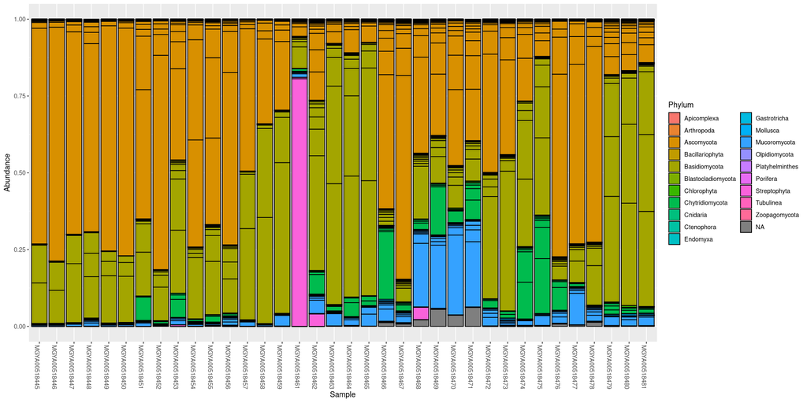

```r
# Transformations of abundances
psglom <- tax_glom(normed_ps, "Order")
normed_ps <- transform_sample_counts(psglom, function(x) x/sum(x))
plot_bar(normed_ps, fill="Phylum")
```

```r
ord <- ordinate(ps, "NMDS", "bray")
```

```
Square root transformation
Wisconsin double standardization
*** Solution reached
```

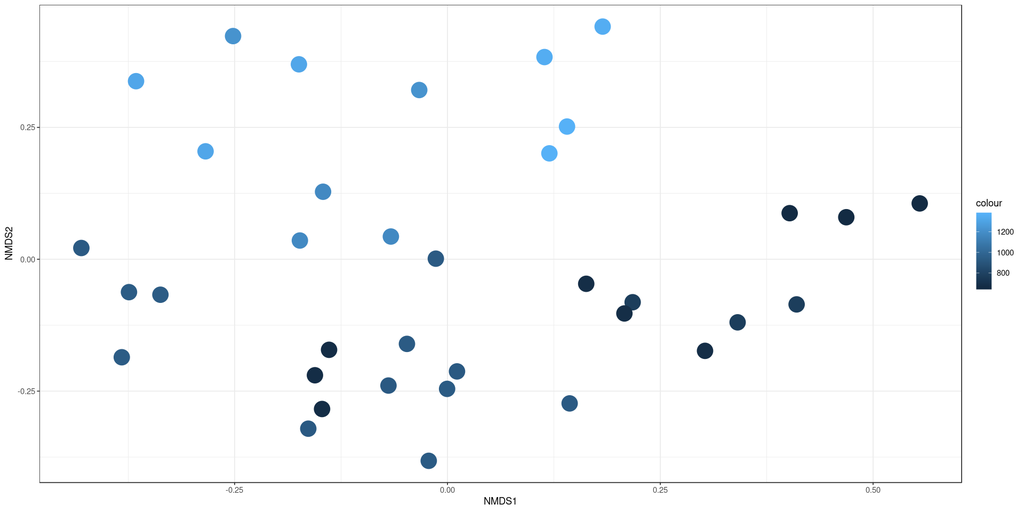

```r
plot_ordination(ps, ord) +
    geom_point(aes(color=as.numeric(sample_elevation)), size=8) +
    theme_bw()
```

## 5 - `mgnify_get_analyses_results`

- Retrieve functional results from API
- Taxonomy also available
  - not OTU based
- `mgnify_get_analyses_results(client, accessions, retrievelist)`
  - `retrievelist` : Which results do you want?
    - availability depends on pipeline and experiment type.
- Returns a list of functional result `data.frames`.

```r
acc_list <- metadata$analysis_accession[metadata$`analysis_experiment-type` == "assembly"]
func_results <- mgnify_get_analyses_results(mg, acc_list, retrievelist = c("go-slim", "taxonomy-ssu") )
```

```r
names(func_results)
```

1. 'go-slim'

2. 'taxonomy-ssu'

```r
func_results$`go-slim`
```

A data.frame: 116 × 19

| accession <chr> | description <chr> | lineage <chr> | MGYA00520940 <int> | MGYA00520966 <int> | MGYA00521001 <int> | MGYA00521025 <int> | MGYA00521063 <int> | MGYA00521064 <int> | MGYA00521126 <int> | MGYA00521127 <int> | MGYA00521190 <int> | MGYA00521191 <int> | MGYA00521216 <int> | MGYA00521217 <int> | MGYA00521258 <int> | MGYA00521259 <int> | MGYA00521311 <int> | MGYA00521312 <int> |
| --- | --- | --- | --- | --- | --- | --- | --- | --- | --- | --- | --- | --- | --- | --- | --- | --- | --- | --- |
| GO:0000015 | phosphopyruvate hydratase complex | cellular_component | 3 | 2 | 1 | 1 | 4 | 0 | 1 | 9 | 1 | 1 | 1 | 1 | 7 | 2 | 2 | 3 |
| GO:0000150 | recombinase activity | molecular_function | 7 | 0 | 2 | 3 | 13 | 9 | 5 | 7 | 0 | 14 | 14 | 5 | 16 | 14 | 16 | 11 |
| GO:0000160 | phosphorelay signal transduction system | biological_process | 79 | 3 | 34 | 0 | 11 | 1 | 59 | 57 | 3 | 92 | 4 | 9 | 65 | 65 | 62 | 85 |
| GO:0000166 | nucleotide binding | molecular_function | 718 | 171 | 272 | 160 | 708 | 104 | 477 | 1298 | 162 | 827 | 330 | 155 | 1137 | 822 | 821 | 993 |
| GO:0003674 | molecular function | molecular_function | 149 | 42 | 55 | 97 | 86 | 25 | 102 | 123 | 28 | 170 | 79 | 80 | 242 | 123 | 150 | 206 |
| GO:0003676 | nucleic acid binding | molecular_function | 760 | 164 | 302 | 227 | 763 | 217 | 528 | 1155 | 157 | 943 | 519 | 237 | 1099 | 889 | 1024 | 1000 |
| GO:0003700 | transcription factor activity, sequence-specific DNA binding | molecular_function | 163 | 4 | 76 | 19 | 38 | 9 | 135 | 114 | 7 | 219 | 20 | 25 | 192 | 153 | 132 | 217 |
| GO:0003735 | structural constituent of ribosome | molecular_function | 95 | 74 | 45 | 58 | 197 | 17 | 68 | 302 | 54 | 70 | 100 | 35 | 225 | 122 | 141 | 141 |
| GO:0003824 | catalytic activity | molecular_function | 583 | 52 | 220 | 60 | 348 | 37 | 335 | 580 | 49 | 649 | 144 | 71 | 640 | 589 | 544 | 702 |
| GO:0004601 | peroxidase activity | molecular_function | 16 | 0 | 2 | 5 | 4 | 0 | 6 | 7 | 0 | 16 | 0 | 0 | 9 | 8 | 12 | 17 |
| GO:0004803 | transposase activiy | molecular_function | 58 | 1 | 14 | 4 | 25 | 10 | 20 | 12 | 0 | 67 | 4 | 6 | 43 | 35 | 42 | 57 |
| GO:0004871 | signal transducer activity | molecular_function | 65 | 6 | 24 | 60 | 66 | 3 | 39 | 49 | 14 | 106 | 42 | 70 | 222 | 53 | 50 | 101 |
| GO:0004872 | receptor activity | molecular_function | 94 | 7 | 30 | 58 | 66 | 5 | 42 | 50 | 14 | 131 | 42 | 81 | 274 | 80 | 72 | 141 |
| GO:0005215 | transporter activity | molecular_function | 677 | 71 | 311 | 85 | 248 | 40 | 412 | 643 | 72 | 757 | 152 | 70 | 757 | 603 | 552 | 814 |
| GO:0005515 | protein binding | molecular_function | 161 | 22 | 50 | 147 | 97 | 17 | 112 | 170 | 22 | 156 | 103 | 139 | 497 | 154 | 138 | 187 |
| GO:0005575 | cellular component | cellular_component | 62 | 2 | 29 | 7 | 4 | 6 | 67 | 8 | 1 | 74 | 5 | 6 | 61 | 73 | 41 | 69 |
| GO:0005576 | extracellular region | cellular_component | 6 | 3 | 2 | 13 | 10 | 3 | 1 | 22 | 3 | 3 | 5 | 9 | 28 | 1 | 8 | 6 |
| GO:0005618 | cell wall | cellular_component | 5 | 0 | 2 | 0 | 3 | 3 | 4 | 14 | 0 | 7 | 1 | 0 | 3 | 5 | 7 | 4 |
| GO:0005622 | intracellular | cellular_component | 144 | 60 | 51 | 85 | 174 | 14 | 99 | 306 | 59 | 129 | 110 | 51 | 312 | 145 | 171 | 188 |
| GO:0005634 | nucleus | cellular_component | 2 | 1 | 0 | 20 | 10 | 0 | 0 | 4 | 0 | 2 | 6 | 24 | 69 | 1 | 2 | 4 |
| GO:0005694 | chromosome | cellular_component | 11 | 4 | 4 | 3 | 17 | 2 | 9 | 26 | 5 | 12 | 5 | 7 | 22 | 11 | 11 | 16 |
| GO:0005727 | extrachromosomal circular DNA | cellular_component | 3 | 1 | 1 | 1 | 8 | 3 | 3 | 7 | 0 | 5 | 3 | 1 | 2 | 8 | 5 | 10 |
| GO:0005737 | cytoplasm | cellular_component | 205 | 40 | 62 | 63 | 132 | 16 | 172 | 331 | 45 | 227 | 60 | 40 | 309 | 208 | 212 | 246 |
| GO:0005839 | proteasome core complex | cellular_component | 5 | 0 | 1 | 8 | 0 | 0 | 1 | 6 | 0 | 3 | 2 | 1 | 11 | 2 | 1 | 5 |
| GO:0005840 | ribosome | cellular_component | 94 | 74 | 44 | 58 | 197 | 17 | 69 | 300 | 53 | 70 | 100 | 34 | 226 | 124 | 142 | 141 |
| GO:0005874 | microtubule | cellular_component | 2 | 2 | 0 | 4 | 3 | 2 | 0 | 3 | 1 | 0 | 4 | 2 | 8 | 1 | 3 | 4 |
| GO:0005886 | plasma membrane | cellular_component | 65 | 2 | 31 | 22 | 34 | 6 | 38 | 62 | 7 | 70 | 19 | 24 | 91 | 50 | 46 | 86 |
| GO:0005975 | carbohydrate metabolic process | biological_process | 311 | 33 | 155 | 41 | 198 | 20 | 184 | 401 | 34 | 354 | 41 | 30 | 350 | 294 | 295 | 351 |
| GO:0006091 | generation of precursor metabolites and energy | biological_process | 94 | 15 | 37 | 19 | 54 | 10 | 58 | 73 | 10 | 95 | 24 | 16 | 123 | 69 | 70 | 112 |
| GO:0006259 | DNA metabolic process | biological_process | 328 | 75 | 129 | 59 | 378 | 126 | 203 | 462 | 59 | 422 | 266 | 88 | 391 | 435 | 468 | 429 |
| ⋮ | ⋮ | ⋮ | ⋮ | ⋮ | ⋮ | ⋮ | ⋮ | ⋮ | ⋮ | ⋮ | ⋮ | ⋮ | ⋮ | ⋮ | ⋮ | ⋮ | ⋮ | ⋮ |
| GO:0019222 | regulation of metabolic process | biological_process | 371 | 14 | 162 | 51 | 119 | 29 | 306 | 310 | 21 | 484 | 63 | 62 | 409 | 350 | 333 | 460 |
| GO:0019842 | vitamin binding | molecular_function | 30 | 3 | 14 | 2 | 15 | 1 | 14 | 27 | 3 | 31 | 10 | 3 | 30 | 28 | 34 | 30 |
| GO:0019867 | outer membrane | cellular_component | 73 | 2 | 16 | 6 | 10 | 7 | 51 | 9 | 1 | 86 | 8 | 6 | 65 | 77 | 73 | 87 |
| GO:0019898 | extrinsic component of membrane | cellular_component | 0 | 0 | 0 | 1 | 0 | 0 | 0 | 0 | 0 | 0 | 1 | 2 | 2 | 0 | 0 | 0 |
| GO:0030170 | pyridoxal phosphate binding | molecular_function | 70 | 2 | 27 | 6 | 26 | 2 | 40 | 63 | 1 | 72 | 12 | 4 | 70 | 60 | 59 | 86 |
| GO:0030246 | carbohydrate binding | molecular_function | 32 | 2 | 8 | 4 | 10 | 1 | 17 | 36 | 0 | 35 | 4 | 6 | 36 | 28 | 24 | 24 |
| GO:0031224 | intrinsic to membrane | cellular_component | 607 | 38 | 249 | 153 | 261 | 32 | 389 | 570 | 45 | 695 | 158 | 141 | 827 | 525 | 496 | 707 |
| GO:0033202 | DNA helicase complex | cellular_component | 1 | 0 | 0 | 0 | 0 | 0 | 1 | 4 | 1 | 1 | 2 | 1 | 1 | 3 | 2 | 2 |
| GO:0042221 | response to chemical | biological_process | 48 | 5 | 31 | 10 | 12 | 1 | 41 | 18 | 3 | 62 | 6 | 2 | 60 | 43 | 29 | 78 |
| GO:0042575 | DNA polymerase complex | cellular_component | 7 | 0 | 2 | 1 | 4 | 0 | 4 | 11 | 1 | 3 | 0 | 0 | 5 | 4 | 6 | 7 |
| GO:0042597 | periplasmic space | cellular_component | 64 | 0 | 23 | 3 | 2 | 3 | 51 | 11 | 0 | 75 | 1 | 4 | 45 | 62 | 40 | 99 |
| GO:0043167 | ion binding | molecular_function | 676 | 162 | 259 | 157 | 681 | 100 | 432 | 1230 | 154 | 763 | 327 | 157 | 1088 | 755 | 772 | 917 |
| GO:0043190 | ATP-binding cassette (ABC) transporter complex | cellular_component | 23 | 1 | 10 | 0 | 2 | 0 | 15 | 16 | 0 | 27 | 2 | 0 | 25 | 21 | 14 | 28 |
| GO:0043934 | sporulation | biological_process | 0 | 0 | 0 | 0 | 4 | 1 | 0 | 1 | 0 | 0 | 4 | 0 | 0 | 1 | 2 | 0 |
| GO:0044281 | small molecule metabolic process | biological_process | 649 | 87 | 233 | 79 | 455 | 48 | 466 | 933 | 106 | 713 | 181 | 68 | 766 | 642 | 627 | 781 |
| GO:0045454 | cell redox homeostasis | biological_process | 23 | 5 | 16 | 8 | 14 | 7 | 19 | 37 | 5 | 34 | 14 | 2 | 30 | 24 | 29 | 32 |
| GO:0046718 | viral entry into host cell | biological_process | 0 | 0 | 0 | 0 | 0 | 0 | 0 | 0 | 0 | 0 | 1 | 0 | 1 | 0 | 1 | 1 |
| GO:0046872 | metal ion binding | molecular_function | 324 | 44 | 111 | 82 | 171 | 31 | 228 | 324 | 42 | 339 | 120 | 73 | 459 | 287 | 299 | 364 |
| GO:0046906 | tetrapyrrole binding | molecular_function | 41 | 2 | 11 | 4 | 15 | 1 | 22 | 11 | 0 | 45 | 9 | 15 | 69 | 31 | 32 | 44 |
| GO:0048500 | signal recognition particle | cellular_component | 3 | 2 | 0 | 1 | 2 | 0 | 1 | 4 | 0 | 0 | 1 | 1 | 4 | 4 | 3 | 1 |
| GO:0050662 | coenzyme binding | molecular_function | 155 | 16 | 66 | 18 | 71 | 9 | 119 | 150 | 17 | 188 | 37 | 19 | 182 | 170 | 156 | 221 |
| GO:0051536 | iron-sulfur cluster binding | molecular_function | 83 | 7 | 25 | 6 | 38 | 5 | 81 | 44 | 9 | 102 | 13 | 6 | 90 | 90 | 60 | 102 |
| GO:0065003 | macromolecular complex assembly | biological_process | 14 | 2 | 2 | 9 | 3 | 0 | 9 | 19 | 0 | 13 | 10 | 3 | 32 | 11 | 11 | 16 |
| GO:0071103 | DNA conformation change | biological_process | 32 | 14 | 16 | 3 | 80 | 17 | 22 | 68 | 7 | 46 | 34 | 4 | 41 | 43 | 56 | 50 |
| GO:0071840 | cellular component organization or biogenesis | biological_process | 96 | 12 | 51 | 12 | 57 | 10 | 85 | 126 | 15 | 125 | 34 | 14 | 126 | 117 | 92 | 134 |
| GO:0071973 | bacterial-type flagellar cell motility | biological_process | 43 | 0 | 22 | 0 | 3 | 1 | 34 | 5 | 0 | 37 | 5 | 0 | 34 | 24 | 21 | 53 |
| GO:0090484 | drug transporter activity | molecular_function | 10 | 2 | 3 | 0 | 8 | 1 | 9 | 11 | 3 | 15 | 3 | 0 | 11 | 9 | 7 | 16 |
| GO:0098796 | membrane protein complex | cellular_component | 11 | 0 | 1 | 11 | 1 | 1 | 2 | 6 | 1 | 8 | 6 | 8 | 29 | 3 | 8 | 6 |
| GO:1902494 | catalytic complex | cellular_component | 10 | 2 | 2 | 6 | 8 | 2 | 11 | 18 | 2 | 13 | 9 | 8 | 41 | 10 | 14 | 16 |
| GO:1990204 | oxidoreductase complex | cellular_component | 24 | 2 | 7 | 4 | 3 | 0 | 21 | 17 | 2 | 20 | 4 | 1 | 23 | 28 | 18 | 29 |

```r
func_results$`taxonomy-ssu`
```

A data.frame: 72 × 24

| phylum <chr> | family <chr> | class <chr> | super.kingdom <chr> | order <chr> | kingdom <chr> | genus <chr> | species <chr> | MGYA00520940 <int> | MGYA00520966 <int> | ⋯ | MGYA00521126 <int> | MGYA00521127 <int> | MGYA00521190 <int> | MGYA00521191 <int> | MGYA00521216 <int> | MGYA00521217 <int> | MGYA00521258 <int> | MGYA00521259 <int> | MGYA00521311 <int> | MGYA00521312 <int> |
| --- | --- | --- | --- | --- | --- | --- | --- | --- | --- | --- | --- | --- | --- | --- | --- | --- | --- | --- | --- | --- |
|  |  |  | Chloroplast |  |  |  | Solanum_commersonii_(Commerson's_wild_potato) | 0 | 1 | ⋯ | 0 | 0 | 0 | 0 | 0 | 0 | 0 | 0 | 0 | 0 |
|  | NA | Phyllopharyngea | Eukaryota | Cyrtophorida |  | NA | NA | 0 | 1 | ⋯ | 0 | 0 | 0 | 0 | 0 | 0 | 0 | 0 | 0 | 0 |
| Actinobacteria | Bifidobacteriaceae | Actinobacteria | Bacteria | Bifidobacteriales |  | NA | NA | 0 | 0 | ⋯ | 0 | 0 | 0 | 0 | 0 | 0 | 0 | 0 | 0 | 1 |
| Actinobacteria | Coriobacteriaceae | Coriobacteriia | Bacteria | Coriobacteriales |  | Collinsella | NA | 0 | 0 | ⋯ | 0 | 0 | 0 | 0 | 0 | 0 | 0 | 0 | 0 | 1 |
| Actinobacteria | Dermatophilaceae | Actinobacteria | Bacteria | Micrococcales |  | NA | NA | 0 | 0 | ⋯ | 0 | 0 | 0 | 0 | 0 | 0 | 0 | 0 | 1 | 0 |
| Actinobacteria | Propionibacteriaceae | Actinobacteria | Bacteria | Propionibacteriales |  | NA | NA | 0 | 0 | ⋯ | 0 | 1 | 0 | 0 | 0 | 0 | 0 | 0 | 0 | 0 |
| Actinobacteria | NA | Actinobacteria | Bacteria | NA |  | NA | NA | 0 | 0 | ⋯ | 0 | 0 | 0 | 0 | 0 | 0 | 0 | 0 | 0 | 0 |
| Apicomplexa | Cryptosporidiidae | Coccidia | Eukaryota | Eucoccidiorida |  | NA | NA | 0 | 0 | ⋯ | 0 | 0 | 0 | 0 | 0 | 0 | 1 | 0 | 0 | 0 |
| Ascomycota | NA | Eurotiomycetes | Eukaryota | Eurotiales | Fungi | NA | NA | 0 | 0 | ⋯ | 0 | 0 | 0 | 0 | 1 | 0 | 0 | 0 | 0 | 0 |
| Bacteroidetes | Bacteroidaceae | Bacteroidia | Bacteria | Bacteroidales |  | Bacteroides | NA | 0 | 0 | ⋯ | 0 | 0 | 0 | 0 | 0 | 0 | 1 | 0 | 0 | 0 |
| Bacteroidetes | Dysgonamonadaceae | Bacteroidia | Bacteria | Bacteroidales |  | NA | NA | 0 | 0 | ⋯ | 0 | 0 | 0 | 0 | 0 | 0 | 0 | 1 | 0 | 0 |
| Bacteroidetes | Flavobacteriaceae | Flavobacteriia | Bacteria | Flavobacteriales |  | Bergeyella | NA | 0 | 0 | ⋯ | 0 | 0 | 0 | 0 | 1 | 0 | 0 | 0 | 0 | 0 |
| Bacteroidetes | Flavobacteriaceae | Flavobacteriia | Bacteria | Flavobacteriales |  | Chryseobacterium | NA | 0 | 0 | ⋯ | 0 | 0 | 0 | 0 | 0 | 0 | 1 | 0 | 0 | 0 |
| Bacteroidetes | Flavobacteriaceae | Flavobacteriia | Bacteria | Flavobacteriales |  | NA | NA | 0 | 0 | ⋯ | 0 | 0 | 0 | 0 | 0 | 0 | 1 | 1 | 0 | 0 |
| Bacteroidetes | Prevotellaceae | Bacteroidia | Bacteria | Bacteroidales |  | NA | NA | 0 | 0 | ⋯ | 0 | 0 | 0 | 1 | 0 | 0 | 0 | 0 | 0 | 0 |
| Bacteroidetes | Sphingobacteriaceae | Sphingobacteriia | Bacteria | Sphingobacteriales |  | Sphingobacterium | Sphingobacterium_sp._CFCC_11742 | 0 | 0 | ⋯ | 0 | 0 | 0 | 0 | 0 | 0 | 0 | 0 | 0 | 0 |
| Bacteroidetes | Sphingobacteriaceae | Sphingobacteriia | Bacteria | Sphingobacteriales |  | Sphingobacterium | NA | 0 | 0 | ⋯ | 0 | 0 | 0 | 0 | 0 | 0 | 0 | 1 | 0 | 0 |
| Bacteroidetes | Sphingobacteriaceae | Sphingobacteriia | Bacteria | Sphingobacteriales |  | NA | NA | 0 | 0 | ⋯ | 0 | 0 | 0 | 0 | 0 | 0 | 0 | 1 | 1 | 0 |
| Chlamydiae | Candidatus_Clavichlamydiaceae | Chlamydiia | Bacteria | Chlamydiales |  | NA | NA | 0 | 0 | ⋯ | 0 | 0 | 0 | 0 | 0 | 0 | 0 | 0 | 0 | 0 |
| Chlamydiae | Chlamydiaceae | Chlamydiia | Bacteria | Chlamydiales |  | NA | NA | 0 | 2 | ⋯ | 0 | 0 | 0 | 0 | 0 | 0 | 0 | 0 | 0 | 2 |
| Chordata | NA | Mammalia | Eukaryota | NA | Metazoa | NA | NA | 0 | 0 | ⋯ | 0 | 0 | 0 | 1 | 0 | 0 | 1 | 1 | 0 | 0 |
| Cyanobacteria | NA |  | Bacteria | Nostocales |  | NA | NA | 0 | 0 | ⋯ | 0 | 0 | 0 | 0 | 1 | 0 | 0 | 0 | 0 | 0 |
| Firmicutes | Clostridiaceae | Clostridia | Bacteria | Clostridiales |  | Clostridium | NA | 0 | 0 | ⋯ | 1 | 0 | 0 | 0 | 1 | 0 | 0 | 0 | 0 | 0 |
| Firmicutes | Enterococcaceae | Bacilli | Bacteria | Lactobacillales |  | Enterococcus | NA | 0 | 0 | ⋯ | 1 | 0 | 0 | 0 | 1 | 0 | 0 | 0 | 1 | 0 |
| Firmicutes | Lachnospiraceae | Clostridia | Bacteria | Clostridiales |  | Blautia | NA | 0 | 0 | ⋯ | 0 | 0 | 0 | 0 | 0 | 0 | 0 | 0 | 0 | 1 |
| Firmicutes | Lachnospiraceae | Clostridia | Bacteria | Clostridiales |  | NA | NA | 0 | 1 | ⋯ | 0 | 1 | 0 | 0 | 0 | 0 | 0 | 0 | 1 | 0 |
| Firmicutes | Lactobacillaceae | Bacilli | Bacteria | Lactobacillales |  | Lactobacillus | NA | 0 | 1 | ⋯ | 0 | 0 | 0 | 0 | 0 | 0 | 0 | 0 | 0 | 1 |
| Firmicutes | Leuconostocaceae | Bacilli | Bacteria | Lactobacillales |  | Weissella | NA | 0 | 0 | ⋯ | 0 | 0 | 0 | 1 | 0 | 0 | 0 | 1 | 0 | 1 |
| Firmicutes | Leuconostocaceae | Bacilli | Bacteria | Lactobacillales |  | NA | NA | 0 | 0 | ⋯ | 0 | 0 | 0 | 0 | 0 | 0 | 1 | 0 | 0 | 0 |
| Firmicutes | Paenibacillaceae | Bacilli | Bacteria | Bacillales |  | Paenibacillus | NA | 0 | 0 | ⋯ | 0 | 0 | 0 | 0 | 1 | 0 | 0 | 0 | 0 | 0 |
| ⋮ | ⋮ | ⋮ | ⋮ | ⋮ | ⋮ | ⋮ | ⋮ | ⋮ | ⋮ | ⋱ | ⋮ | ⋮ | ⋮ | ⋮ | ⋮ | ⋮ | ⋮ | ⋮ | ⋮ | ⋮ |
| Proteobacteria | Burkholderiaceae | Betaproteobacteria | Bacteria | Burkholderiales |  | Ralstonia | NA | 0 | 0 | ⋯ | 0 | 0 | 0 | 0 | 0 | 0 | 1 | 0 | 1 | 0 |
| Proteobacteria | Campylobacteraceae | Epsilonproteobacteria | Bacteria | Campylobacterales |  | NA | NA | 0 | 0 | ⋯ | 0 | 0 | 0 | 0 | 0 | 0 | 0 | 0 | 0 | 0 |
| Proteobacteria | Comamonadaceae | Betaproteobacteria | Bacteria | Burkholderiales |  | NA | NA | 1 | 0 | ⋯ | 0 | 0 | 0 | 1 | 0 | 0 | 0 | 0 | 0 | 1 |
| Proteobacteria | Enterobacteriaceae | Gammaproteobacteria | Bacteria | Enterobacterales |  | NA | NA | 0 | 0 | ⋯ | 0 | 0 | 0 | 1 | 1 | 0 | 0 | 1 | 1 | 0 |
| Proteobacteria | Helicobacteraceae | Epsilonproteobacteria | Bacteria | Campylobacterales |  | NA | NA | 0 | 0 | ⋯ | 0 | 0 | 0 | 0 | 0 | 0 | 0 | 1 | 0 | 0 |
| Proteobacteria | Moraxellaceae | Gammaproteobacteria | Bacteria | Pseudomonadales |  | Acinetobacter | NA | 1 | 0 | ⋯ | 0 | 0 | 0 | 0 | 0 | 0 | 0 | 0 | 0 | 0 |
| Proteobacteria | Neisseriaceae | Betaproteobacteria | Bacteria | Neisseriales |  | Kingella | NA | 1 | 0 | ⋯ | 0 | 0 | 0 | 0 | 0 | 0 | 0 | 0 | 0 | 0 |
| Proteobacteria | Neisseriaceae | Betaproteobacteria | Bacteria | Neisseriales |  | NA | NA | 0 | 0 | ⋯ | 0 | 0 | 0 | 0 | 1 | 0 | 0 | 0 | 0 | 0 |
| Proteobacteria | Rhodobacteraceae | Alphaproteobacteria | Bacteria | Rhodobacterales |  | NA | NA | 2 | 0 | ⋯ | 0 | 0 | 0 | 1 | 0 | 0 | 0 | 0 | 0 | 2 |
| Proteobacteria | Sphingomonadaceae | Alphaproteobacteria | Bacteria | Sphingomonadales |  | NA | NA | 0 | 0 | ⋯ | 0 | 0 | 0 | 0 | 1 | 0 | 0 | 0 | 0 | 0 |
| Proteobacteria | Xanthomonadaceae | Gammaproteobacteria | Bacteria | Xanthomonadales |  | Stenotrophomonas | NA | 0 | 1 | ⋯ | 0 | 0 | 0 | 0 | 0 | 0 | 0 | 0 | 0 | 0 |
| Proteobacteria | Yersiniaceae | Gammaproteobacteria | Bacteria | Enterobacterales |  | Serratia | Serratia_sp._Ag1 | 0 | 0 | ⋯ | 0 | 0 | 0 | 0 | 0 | 0 | 0 | 0 | 1 | 0 |
| Proteobacteria | NA | Alphaproteobacteria | Bacteria | Sphingomonadales |  | NA | NA | 0 | 0 | ⋯ | 0 | 0 | 0 | 0 | 0 | 0 | 0 | 0 | 0 | 0 |
| Proteobacteria | NA | Betaproteobacteria | Bacteria | Burkholderiales |  | NA | NA | 0 | 0 | ⋯ | 0 | 1 | 0 | 0 | 0 | 1 | 1 | 0 | 0 | 0 |
| Proteobacteria | NA | Betaproteobacteria | Bacteria | NA |  | NA | NA | 1 | 0 | ⋯ | 0 | 0 | 0 | 0 | 0 | 0 | 0 | 0 | 0 | 0 |
| Proteobacteria | NA | Gammaproteobacteria | Bacteria | Enterobacterales |  | NA | NA | 0 | 0 | ⋯ | 0 | 0 | 0 | 0 | 1 | 0 | 0 | 0 | 0 | 0 |
| Proteobacteria | NA | Gammaproteobacteria | Bacteria | NA |  | NA | NA | 1 | 1 | ⋯ | 0 | 0 | 0 | 0 | 0 | 0 | 1 | 1 | 1 | 0 |
| Proteobacteria | NA | Oligoflexia | Bacteria | Oligoflexales |  | NA | NA | 0 | 0 | ⋯ | 0 | 0 | 0 | 0 | 0 | 1 | 0 | 0 | 0 | 0 |
| Proteobacteria | NA | NA | Bacteria | NA |  | NA | NA | 0 | 0 | ⋯ | 0 | 0 | 0 | 0 | 0 | 0 | 1 | 0 | 0 | 0 |
| Spirochaetes | Spirochaetaceae | Spirochaetia | Bacteria | Spirochaetales |  | NA | NA | 0 | 0 | ⋯ | 0 | 2 | 0 | 0 | 0 | 0 | 0 | 0 | 0 | 0 |
| Streptophyta | NA | NA | Eukaryota | NA | Viridiplantae | NA | NA | 0 | 0 | ⋯ | 0 | 1 | 0 | 0 | 1 | 0 | 2 | 1 | 0 | 1 |
| Tenericutes | Mycoplasmataceae | Mollicutes | Bacteria | Mycoplasmatales |  | Mycoplasma | NA | 1 | 3 | ⋯ | 0 | 0 | 1 | 1 | 3 | 0 | 2 | 0 | 1 | 3 |
| Tenericutes | Mycoplasmataceae | Mollicutes | Bacteria | Mycoplasmatales |  | Ureaplasma | NA | 0 | 0 | ⋯ | 0 | 3 | 0 | 0 | 0 | 0 | 0 | 0 | 0 | 0 |
| Tenericutes | Mycoplasmataceae | Mollicutes | Bacteria | Mycoplasmatales |  | NA | NA | 1 | 0 | ⋯ | 0 | 1 | 0 | 0 | 0 | 0 | 0 | 0 | 0 | 0 |
| Tenericutes | NA | Mollicutes | Bacteria | Mycoplasmatales |  | NA | NA | 0 | 0 | ⋯ | 0 | 0 | 0 | 0 | 0 | 0 | 0 | 0 | 0 | 1 |
| NA | NA | NA | Bacteria | NA | NA | NA | NA | 0 | 1 | ⋯ | 0 | 0 | 1 | 0 | 1 | 0 | 1 | 2 | 0 | 0 |
| NA | NA | NA | Chloroplast | NA | NA | NA | NA | 0 | 1 | ⋯ | 0 | 0 | 0 | 0 | 0 | 0 | 3 | 0 | 0 | 0 |
| NA | NA | NA | Eukaryota | NA | Metazoa | NA | NA | 0 | 2 | ⋯ | 1 | 0 | 1 | 0 | 1 | 1 | 0 | 0 | 1 | 0 |
| NA | NA | NA | Eukaryota | NA | NA | NA | NA | 0 | 1 | ⋯ | 0 | 0 | 1 | 1 | 0 | 0 | 1 | 0 | 0 | 0 |
| NA | NA | NA | Mitochondria | NA | NA | NA | NA | 0 | 0 | ⋯ | 0 | 0 | 0 | 0 | 0 | 1 | 0 | 0 | 0 | 2 |

- Can be **slow** - especially for Interpro.
- Extra option - `bulk_dl`
  - Flag to retrieve per-study results
  - not always reliable
  - **Extremely** fast when it works
    - so try it - warnings will be issued

```r
#This still using the local cache, but on a per-analysis basis
tmp <- mgnify_get_analyses_results(mg, acc_list, retrievelist = c("interpro-identifiers") )
```

```r
tmp2 <- mgnify_get_analyses_results(mg, acc_list, retrievelist = c("interpro-identifiers"), bulk_dl=T )
```

```r
head(tmp$`interpro-identifiers` == tmp2$`interpro-identifiers`)
```

A matrix: 6 × 18 of type lgl

| accession | description | MGYA00520940 | MGYA00520966 | MGYA00521001 | MGYA00521025 | MGYA00521063 | MGYA00521064 | MGYA00521126 | MGYA00521127 | MGYA00521190 | MGYA00521191 | MGYA00521216 | MGYA00521217 | MGYA00521258 | MGYA00521259 | MGYA00521311 | MGYA00521312 |
| --- | --- | --- | --- | --- | --- | --- | --- | --- | --- | --- | --- | --- | --- | --- | --- | --- | --- |
| TRUE | TRUE | TRUE | TRUE | TRUE | TRUE | TRUE | TRUE | TRUE | TRUE | TRUE | TRUE | TRUE | TRUE | TRUE | TRUE | TRUE | TRUE |
| TRUE | TRUE | TRUE | TRUE | TRUE | TRUE | TRUE | TRUE | TRUE | TRUE | TRUE | TRUE | TRUE | TRUE | TRUE | TRUE | TRUE | TRUE |
| TRUE | TRUE | TRUE | TRUE | TRUE | TRUE | TRUE | TRUE | TRUE | TRUE | TRUE | TRUE | TRUE | TRUE | TRUE | TRUE | TRUE | TRUE |
| TRUE | TRUE | TRUE | TRUE | TRUE | TRUE | TRUE | TRUE | TRUE | TRUE | TRUE | TRUE | TRUE | TRUE | TRUE | TRUE | TRUE | TRUE |
| TRUE | TRUE | TRUE | TRUE | TRUE | TRUE | TRUE | TRUE | TRUE | TRUE | TRUE | TRUE | TRUE | TRUE | TRUE | TRUE | TRUE | TRUE |
| TRUE | TRUE | TRUE | TRUE | TRUE | TRUE | TRUE | TRUE | TRUE | TRUE | TRUE | TRUE | TRUE | TRUE | TRUE | TRUE | TRUE | TRUE |

# 6 - `mgnify_download` - get raw results files.

- Intended for retrieval of larger TSV and FASTA files
- multistep process:
  - `mgnify_get_download_urls` - what's available
  - `mgnify_download` - Actually retrieve the file
- `mgnify_get_download_urls(client, accessions, accession_type)`
  - `accession_type` - `assemblies`, `analyses`, `studies` etc
  - Returns `data.frame` -includes file type, format and location URL `download_url` is what you want.

```r
dl_df <- mgnify_get_download_urls(mg, acc_list, "analyses")
head(dl_df)
```

A data.frame: 6 × 17

| type <chr> | id <chr> | attributes.alias <chr> | attributes.file.format.name <chr> | attributes.file.format.compression <lgl> | attributes.file.format.extension <chr> | attributes.description.label <chr> | attributes.description.description <chr> | attributes.group.type <chr> | attributes.file.checksum.checksum.algorithm <chr> | attributes.file.checksum.checksum <chr> | relationships.pipeline.related <chr> | relationships.pipeline.data.type <chr> | relationships.pipeline.data.id <chr> | download_url <chr> | accession <chr> | accession_type <chr> |
| --- | --- | --- | --- | --- | --- | --- | --- | --- | --- | --- | --- | --- | --- | --- | --- | --- |
| analysis-job-downloads | ERZ809583_FASTA.fasta.gz | ERZ809583_FASTA.fasta.gz | FASTA | TRUE | fasta | Processed contigs | Processed contigs | Sequence data |  |  | https://www.ebi.ac.uk/metagenomics/api/v1/pipelines/4.1?format=json | pipelines | 4.1 | https://www.ebi.ac.uk/metagenomics/api/v1/analyses/MGYA00520940/file/ERZ809583_FASTA.fasta.gz | MGYA00520940 | analyses |
| analysis-job-downloads | ERZ809583_FASTA_CDS_annotated.faa.gz | ERZ809583_FASTA_CDS_annotated.faa.gz | FASTA | TRUE | fasta | Predicted CDS with annotation | Predicted coding sequences with InterPro match (FASTA) | Sequence data |  |  | https://www.ebi.ac.uk/metagenomics/api/v1/pipelines/4.1?format=json | pipelines | 4.1 | https://www.ebi.ac.uk/metagenomics/api/v1/analyses/MGYA00520940/file/ERZ809583_FASTA_CDS_annotated.faa.gz | MGYA00520940 | analyses |
| analysis-job-downloads | ERZ809583_FASTA_CDS_unannotated.faa.gz | ERZ809583_FASTA_CDS_unannotated.faa.gz | FASTA | TRUE | fasta | Predicted CDS without annotation | Predicted CDS without annotation | Sequence data |  |  | https://www.ebi.ac.uk/metagenomics/api/v1/pipelines/4.1?format=json | pipelines | 4.1 | https://www.ebi.ac.uk/metagenomics/api/v1/analyses/MGYA00520940/file/ERZ809583_FASTA_CDS_unannotated.faa.gz | MGYA00520940 | analyses |
| analysis-job-downloads | ERZ809583_FASTA_contigsWithpCDS.fasta.gz | ERZ809583_FASTA_contigsWithpCDS.fasta.gz | FASTA | TRUE | fasta | Processed contigs with pCDS | All contigs that have predicted CDS | Sequence data |  |  | https://www.ebi.ac.uk/metagenomics/api/v1/pipelines/4.1?format=json | pipelines | 4.1 | https://www.ebi.ac.uk/metagenomics/api/v1/analyses/MGYA00520940/file/ERZ809583_FASTA_contigsWithpCDS.fasta.gz | MGYA00520940 | analyses |
| analysis-job-downloads | ERZ809583_FASTA_interproscan.fasta.gz | ERZ809583_FASTA_interproscan.fasta.gz | FASTA | TRUE | fasta | Processed contigs with annotation | All contigs with an interproscan match | Sequence data |  |  | https://www.ebi.ac.uk/metagenomics/api/v1/pipelines/4.1?format=json | pipelines | 4.1 | https://www.ebi.ac.uk/metagenomics/api/v1/analyses/MGYA00520940/file/ERZ809583_FASTA_interproscan.fasta.gz | MGYA00520940 | analyses |
| analysis-job-downloads | ERZ809583_FASTA_noFunction.fasta.gz | ERZ809583_FASTA_noFunction.fasta.gz | FASTA | TRUE | fasta | Processed contigs without annotation | All contigs with a predicted CDS but no interproscan match | Sequence data |  |  | https://www.ebi.ac.uk/metagenomics/api/v1/pipelines/4.1?format=json | pipelines | 4.1 | https://www.ebi.ac.uk/metagenomics/api/v1/analyses/MGYA00520940/file/ERZ809583_FASTA_noFunction.fasta.gz | MGYA00520940 | analyses |

- `mgnify_download(client, url, target_filename, readfunc)`
  - `target_filename` - where to store the downloaded file. Default to cache folder
  - `readfunc` - function to process file "inline".
- Returns downloaded file location
  - in cache or `target_filename`

```r
#Choosing a single file
analysis_subset = dl_df$accession == "MGYA00520940"
ftype_subset = dl_df$attributes.description.label == "Predicted ORF with annotation"


file_url = dl_df$download_url[analysis_subset & ftype_subset]

file_url
```

'https://www.ebi.ac.uk/metagenomics/api/v1/analyses/MGYA00520940/file/ERZ809583_FASTA_ORF_annotated.ffn.gz'

```r
mgnify_download(mg, file_url)
```

'~/MyLocalMGnifyCache/analyses/MGYA00520940/file/ERZ809583_FASTA_ORF_annotated.ffn.gz'

```r
(file_location <- mgnify_download(mg, file_url, target_filename = "~/Metagenomics/Proteins.fasta"))
```

'~/Metagenomics/Proteins.fasta'

```r
library(Biostrings)
readAAStringSet(file_location)
```

```
  A AAStringSet instance of length 9746
       width seq                                            names
   [1]   885 ATGTTTACTAAAGCATTGAAAT...GAAATGGTTGACAGCAAATAA ERZ809583.1-NODE-...
   [2]   729 GTGATTAAAGATTTCTTTAAAG...ATTAAATCTATCGTTGGATAA ERZ809583.1-NODE-...
   [3]  1311 TTGAAACAGATTAAAACAACAT...ACTTGGGAACCATTAGAATAA ERZ809583.1-NODE-...
   [4]   594 ATGAATATTAACTTAAATGTTA...GATACTACTGGTGAAATGTAA ERZ809583.1-NODE-...
   [5]   252 ATGGCAGGATATCATTTAGATG...GAAGGTGGATATAGAAAATGA ERZ809583.1-NODE-...
   ...   ... ...
[9742]   507 CCAGGAGTGAACAACCAGCCCT...ACACCGCCGCCTCCTTACACC ERZ809583.7829-NO...
[9743]   135 GAAGAAGTGAACGTCATTACCT...ATGGGTACCCGTAGCGGTGAT ERZ809583.7830-NO...
[9744]   501 GTTGGGTGTGTTTGGGCGGCGG...CCCTTCACCAAACACACCCAA ERZ809583.7930-NO...
[9745]   249 TTGGTGATGGGCGCAACCTTCC...AGTCTTGAACACAGCGTCGGA ERZ809583.8020-NO...
[9746]   288 ACCGCTACCGGCGATGGTCTGT...ATACTGGCCTTGCAGGACAAA ERZ809583.8193-NO...
```

# Wrapping up

- Don't worry if you didn't follow it all.
  - Read the vignette
- *Please* give feedback - `ben.allen@ncl.ac.uk`
  - Current structure biased to what I think is needed.
- Have a go at the exercises
  - but there's a lot to do...

It's a lot to take in at once And clearly requires reasonable R abilities.